# CS 1675 Final Project

Example: save and reload a model object

Graham Zug

## Part 0: Setting The Workspace Up

This part is just loading in packages and data, as well as splitting the data up logically (e.g. dividing the response 1 from the response 2 inputs). ## Load packages

```r
library(caret)
library(tidyverse)
library(rstanarm)
library(dotwhisker)
library(broom.mixed)
```

```r
library(dplyr)
library(ggplot2)
library(e1071)
library(neuralnet)
library(plotROC)
```

## Final project data

```r
data_url <- 'https://raw.githubusercontent.com/jyurko/CS_1675_Fall_2020/master/HW/final_project/cs_1675_final_project_data.csv'

df <- readr::read_csv(data_url, col_names = TRUE)
```

Separate the variables associated with Step 1.

```r
step_1_df <- df %>% select(xA, xB, x01:x06, response_1)
```

Separate the variables associated with the Option B classification formulation. Notice that the `outcome_2` variable is converted to a factor with a specific ordering of the levels. Use this ordering when modeling in `caret` to make sure everyone predicts the `Fail` class as the “positive” class in the confusion matrix.

```r
step_2_b_df <- df %>% select(xA, xB, response_1, x07:x11, outcome_2) %>%
  mutate(outcome_2 = factor(outcome_2, levels = c("Fail", "Pass")))
```

Separate the variables associated with the Option A classification formulation. The `outcome_2` variable is again converted to a factor with a specific ordering of the levels.

```r
step_2_a_df <- df %>% select(xA, xB, x01:x11, outcome_2) %>%
  mutate(outcome_2 = factor(outcome_2, levels = c("Fail", "Pass")))
```

##Part 1: Visualizing the Data

The very first thing I’d like to do is call glimpse(), just to get an idea of the kinds of variables I’m working with:

```r
df %>% glimpse()
```

```
## Rows: 2,013
## Columns: 15
## $ xA         <chr> "A1", "A1", "A1", "A1", "A1", "A1", "A1", "A1", "A1", "A...
## $ xB         <chr> "B1", "B1", "B1", "B1", "B1", "B1", "B1", "B1", "B1", "B...
## $ x01        <dbl> 116.0243, 116.2233, 120.0090, 116.7899, 118.6890, 114.86...
## $ x02        <dbl> 67.22126, 67.22322, 67.99413, 67.58773, 66.92224, 66.513...
## $ x03        <dbl> 157.6709, 150.4697, 155.5444, 159.4190, 154.8513, 150.64...
## $ x04        <dbl> 106.91331, 103.83730, 105.16593, 107.16210, 104.50367, 9...
## $ x05        <dbl> 99.50679, 97.95972, 102.59383, 91.41536, 107.61530, 80.8...
## $ x06        <dbl> 97.16579, 97.83493, 96.89123, 98.71637, 97.41629, 97.168...
## $ x07        <dbl> 142.0740, 142.9439, 144.9922, 145.0192, 145.8730, 144.91...
## $ x08        <dbl> 77.24619, 76.62125, 78.07184, 78.09906, 77.68426, 76.430...
## $ x09        <dbl> 135.8401, 137.1560, 137.3799, 137.2304, 135.3791, 135.88...
## $ x10        <dbl> 62.29576, 62.29373, 63.88513, 54.03932, 63.33956, 65.590...
## $ x11        <dbl> 106.7585, 106.4500, 106.8000, 106.9970, 106.1210, 107.93...
## $ response_1 <dbl> -0.87151245, 3.24318586, 4.47627039, -0.02065380, 0.0647...
## $ outcome_2  <chr> "Pass", "Fail", "Pass", "Pass", "Fail", "Fail", "Pass", ...
```

The next thing I’m going to do is get some counts from the discrete data points. The only sets that seem discrete are xA, xB, and outcome_2. outcome_2 is what we are trying to predict, so it’d be nice to see how often we’d expect to get a pass at random:

```r
count(df, vars = outcome_2)
```

```
## # A tibble: 2 x 2
##   vars      n
##   <chr> <int>
## 1 Fail    985
## 2 Pass   1028
```

Huh! so outcome_2 is very balanced, we are only getting a pass about 51.1% of the time. This is going to be helpful to note going forward as it informs us a bit about what a “good” model looks like. Succeeding more than 48.9% of the time at detecting failure is an improvement over chance. Now lets see the relationship between outcome_2 and the other discrete variables:

```r
count(df, vars = xA)
```

```
## # A tibble: 2 x 2
##   vars      n
##   <chr> <int>
## 1 A1      847
## 2 A2     1166
```

```r
count(df, vars = xB)
```

```
## # A tibble: 4 x 2
##   vars      n
##   <chr> <int>
## 1 B1      463
## 2 B2      585
## 3 B3      537
## 4 B4      428
```

```r
prop.table(table(df %>% select(xA,outcome_2)), 1)
```

```
##     outcome_2
## xA        Fail      Pass
##   A1 0.4970484 0.5029516
##   A2 0.4837050 0.5162950
```

```r
prop.table(table(df %>% select(xB,outcome_2)), 1)
```

```
##     outcome_2
## xB        Fail      Pass
##   B1 0.5140389 0.4859611
##   B2 0.3897436 0.6102564
##   B3 0.4655493 0.5344507
##   B4 0.6285047 0.3714953
```

Some things stand out here. The first thing to note is that we have a fairly evenly distributed amount of each variable (there is no variable that is occurring that much more than any other, and we have a sample size of at least hundreds for all variables). The other thing to note is that our choice of xA does not seems to have a significant effect on the overall outcome, but our choice of xB does seem to have a significant effect. B2, for example, passes 61% of the time, whereas B4 fails almost 63% of the time, we will need to analyze the relationship between the choices of inputs associated with these variables, but we can say that if, for example, our model says that B4 maximizes our chances of passing better than B2, we will be surprised.

## Relationship between response_1 and outcome_2

Branching out further into other variables, let us investiage the relationship between response_1 and outcome_2. This will help us try to get an idea for what we are looking for when manipulating response_1. Are we trying to minimize it, or maximize it? Does it look like it has a linear relationship with outcome_2? etc.

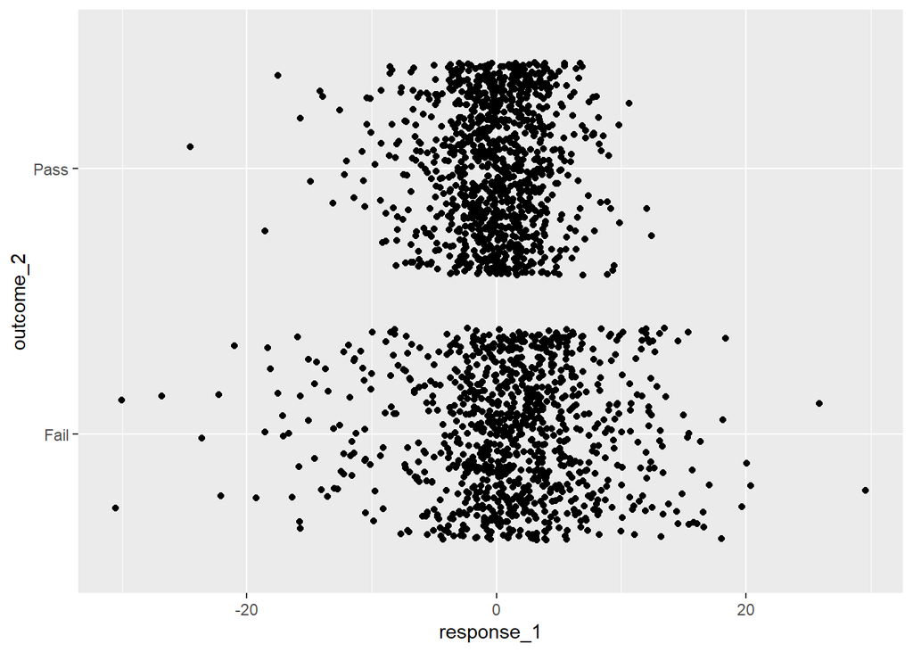

```r
df %>% ggplot(aes(response_1,outcome_2)) + geom_jitter()
```

It appears from this visualization that passing is associated with response_1 being closer to 0.

```r
response_1_partitioned <- ifelse(abs(df$response_1) < 1, 1, 0)
response_1_partitioned <- as.data.frame(response_1_partitioned) %>% mutate("3" = ifelse(abs(df$response_1) < 3, 1, 0))
response_1_partitioned <- response_1_partitioned %>% mutate("5" = ifelse(abs(df$response_1) < 5, 1, 0))
response_1_partitioned <- response_1_partitioned %>% mutate("10" = ifelse(abs(df$response_1) < 10, 1, 0))
response_1_partitioned <- response_1_partitioned %>% mutate("20" = ifelse(abs(df$response_1) < 20, 1, 0))
response_1_partitioned <- as.data.frame(response_1_partitioned) %>% mutate(outcome = df$outcome_2)
prop.table(table(response_1_partitioned %>% select(response_1_partitioned,outcome)), 1)
```

```
##                       outcome
## response_1_partitioned      Fail      Pass
##                      0 0.5122873 0.4877127
##                      1 0.4037559 0.5962441
```

```r
prop.table(table(response_1_partitioned %>% select("3",outcome)), 1)
```

```
##    outcome
## 3        Fail      Pass
##   0 0.5960044 0.4039956
##   1 0.4028777 0.5971223
```

```r
prop.table(table(response_1_partitioned %>% select("5",outcome)), 1)
```

```
##    outcome
## 5        Fail      Pass
##   0 0.6908023 0.3091977
##   1 0.4207723 0.5792277
```

```r
prop.table(table(response_1_partitioned %>% select("10",outcome)), 1)
```

```
##    outcome
## 10       Fail      Pass
##   0 0.8589744 0.1410256
##   1 0.4582660 0.5417340
```

```r
prop.table(table(response_1_partitioned %>% select("20",outcome)), 1)
```

```
##    outcome
## 20        Fail       Pass
##   0 0.91666667 0.08333333
##   1 0.48675662 0.51324338
```

As one can see from the above probability tables, the rate of failure increases as the absolute value of response1 gets greater and greater.

## Relationship between response_1 and outcome_2 with other variables

We will now explore the relationship between outputs 1-6 and responses 1, as well as the relationship between xA and xB with response 1.

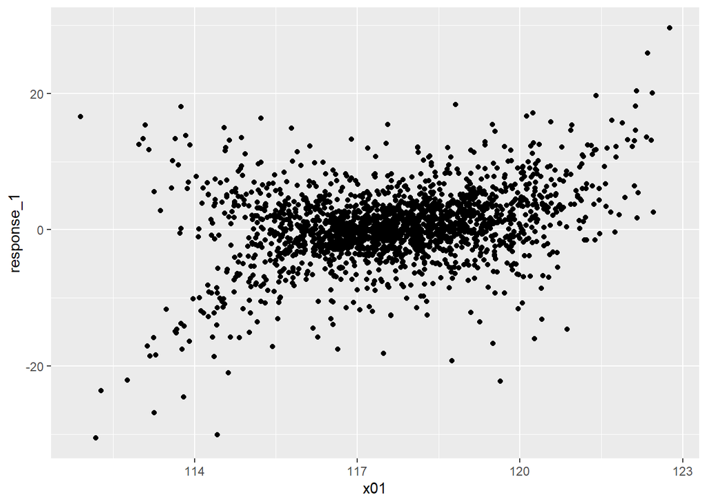

```r
df %>% ggplot(aes(x01,response_1)) + geom_point()
```

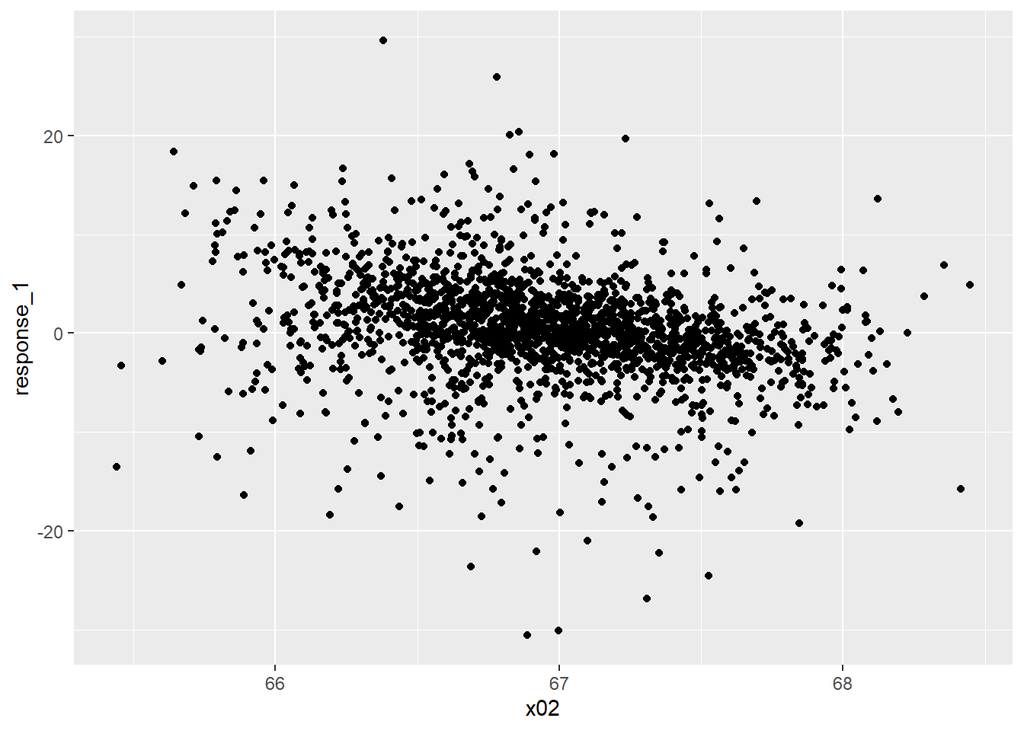

```r
df %>% ggplot(aes(x02,response_1)) + geom_point()
```

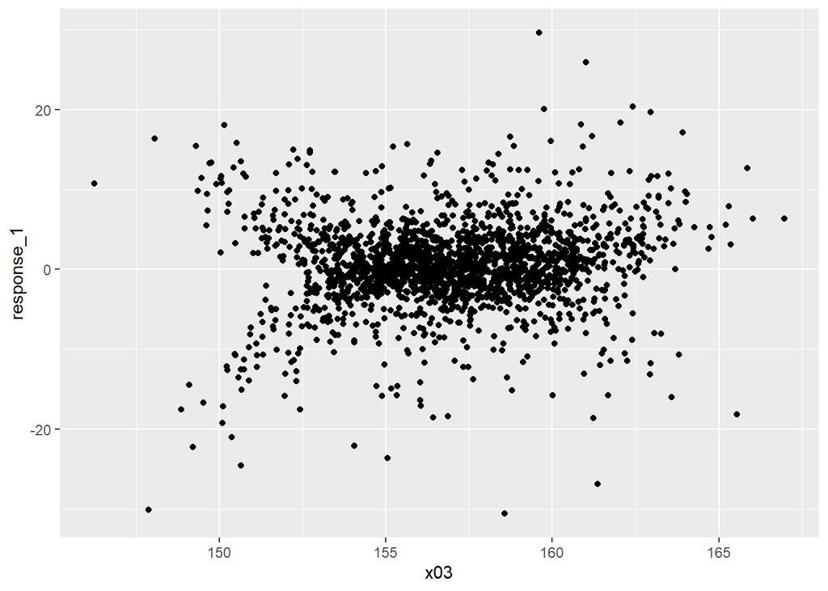

```r
df %>% ggplot(aes(x03,response_1)) + geom_point()
```

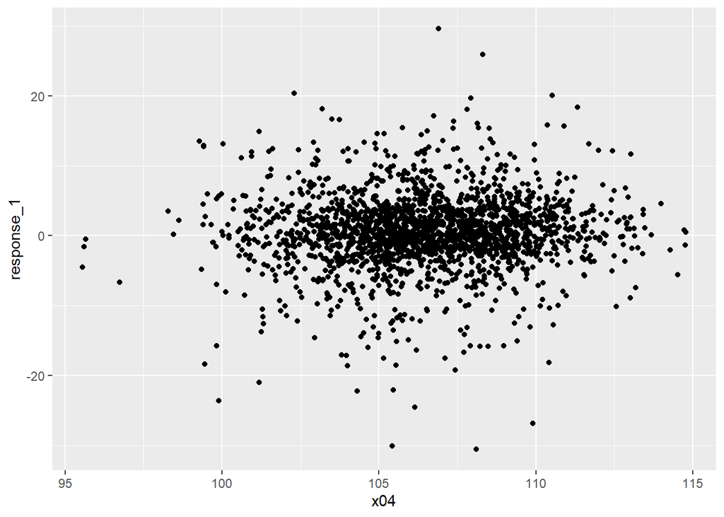

```r
df %>% ggplot(aes(x04,response_1)) + geom_point()
```

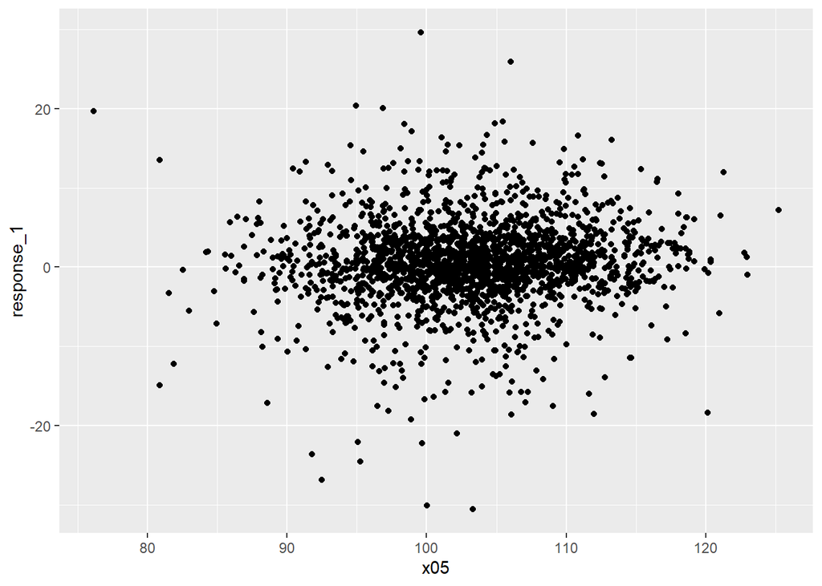

```r
df %>% ggplot(aes(x05,response_1)) + geom_point()
```

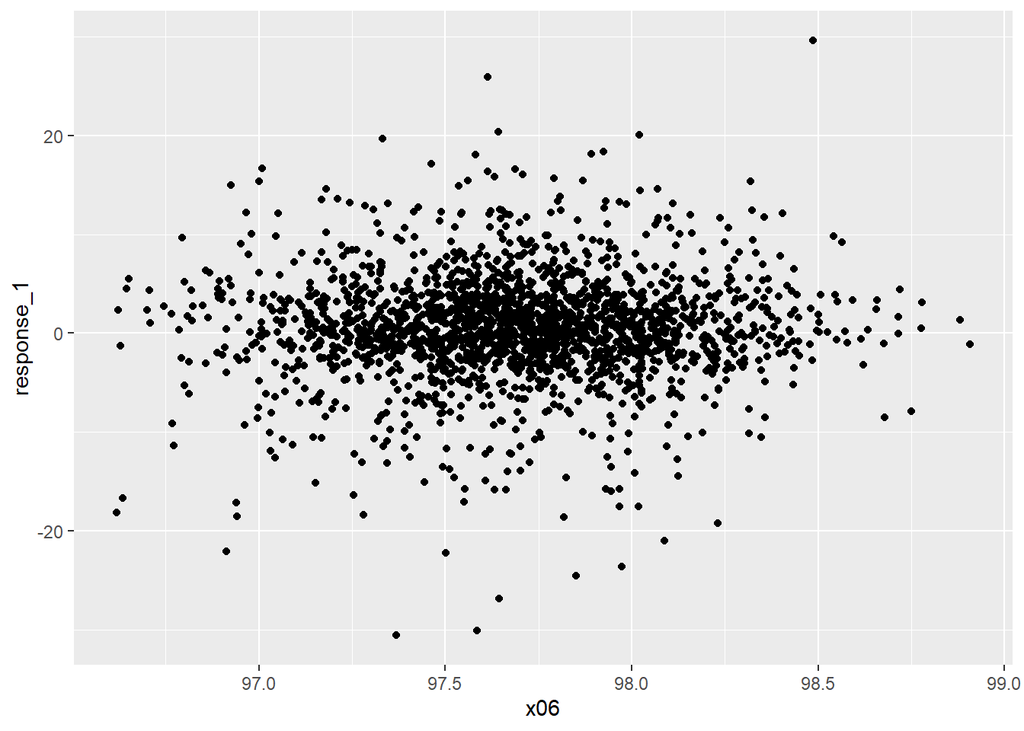

```r
df %>% ggplot(aes(x06,response_1)) + geom_point()
```

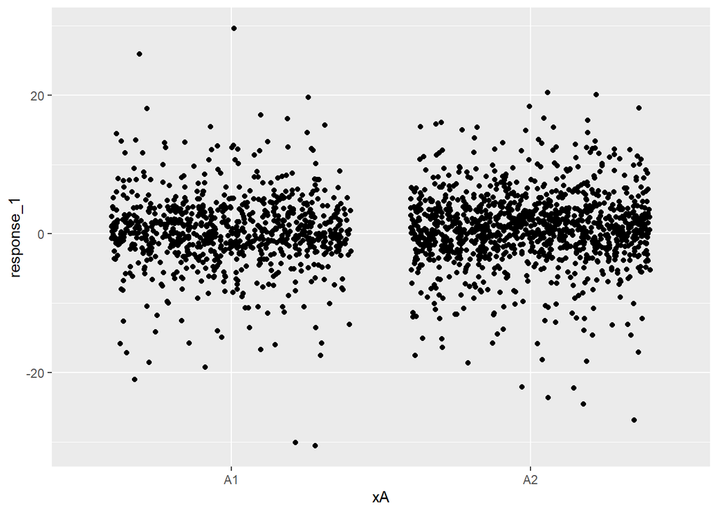

```r
df %>% ggplot(aes(xA,response_1)) + geom_jitter()
```

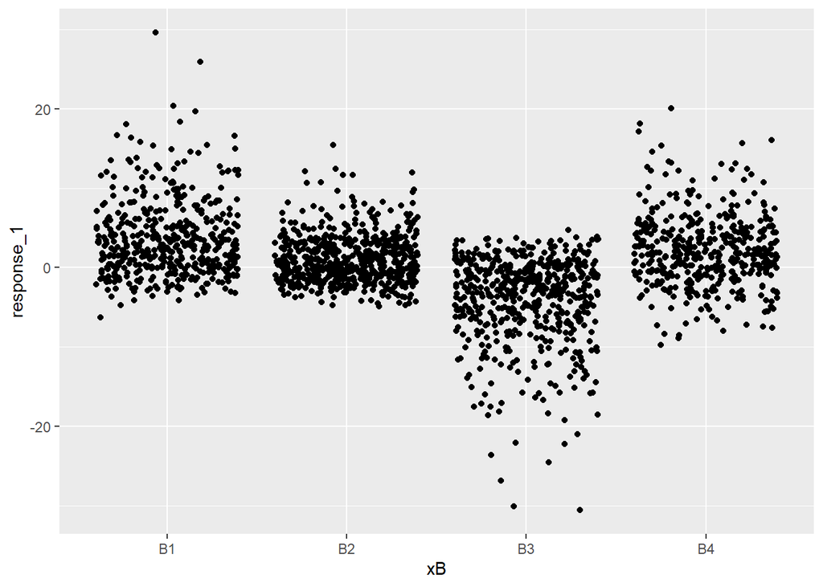

```r
df %>% ggplot(aes(xB,response_1)) + geom_jitter()
```

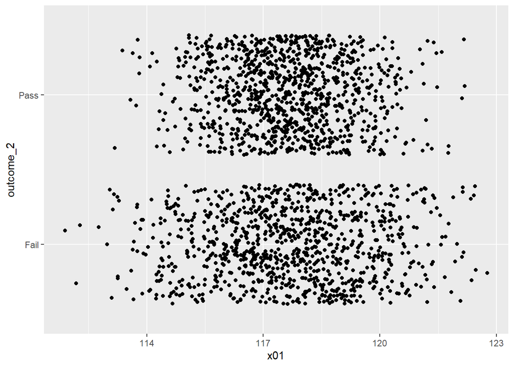

```r
df %>% ggplot(aes(x01,outcome_2)) + geom_jitter()
```

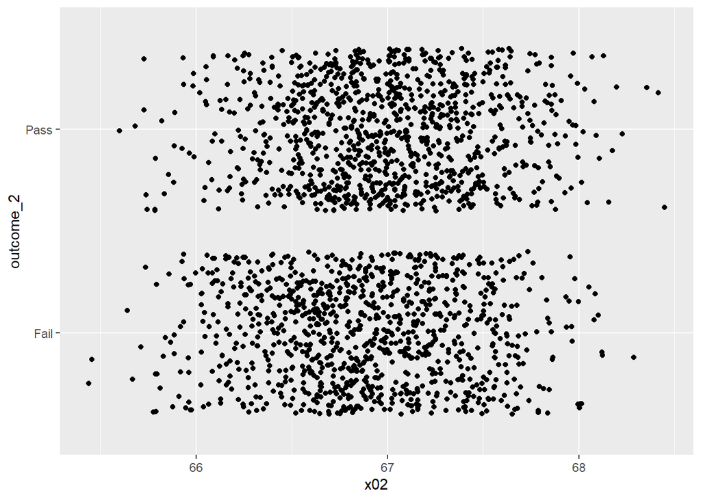

```r
df %>% ggplot(aes(x02,outcome_2)) + geom_jitter()
```

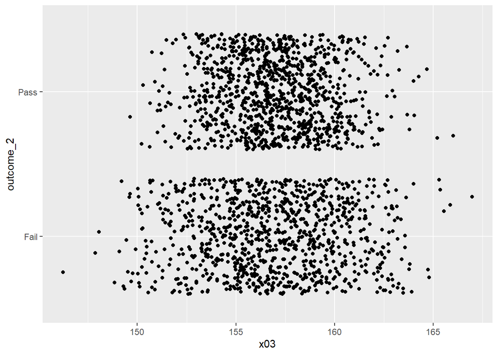

```r
df %>% ggplot(aes(x03,outcome_2)) + geom_jitter()
```

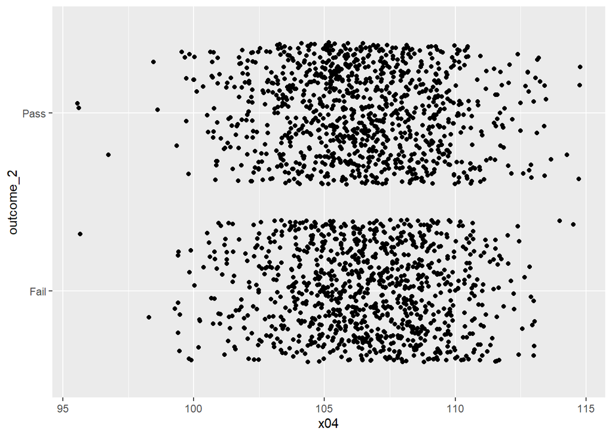

```r
df %>% ggplot(aes(x04,outcome_2)) + geom_jitter()
```

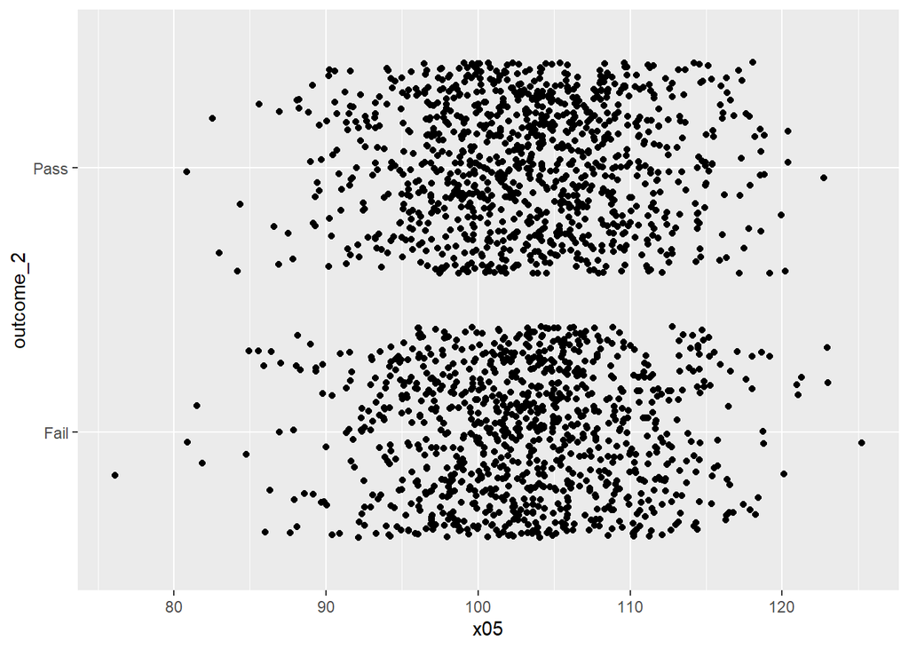

```r
df %>% ggplot(aes(x05,outcome_2)) + geom_jitter()
```

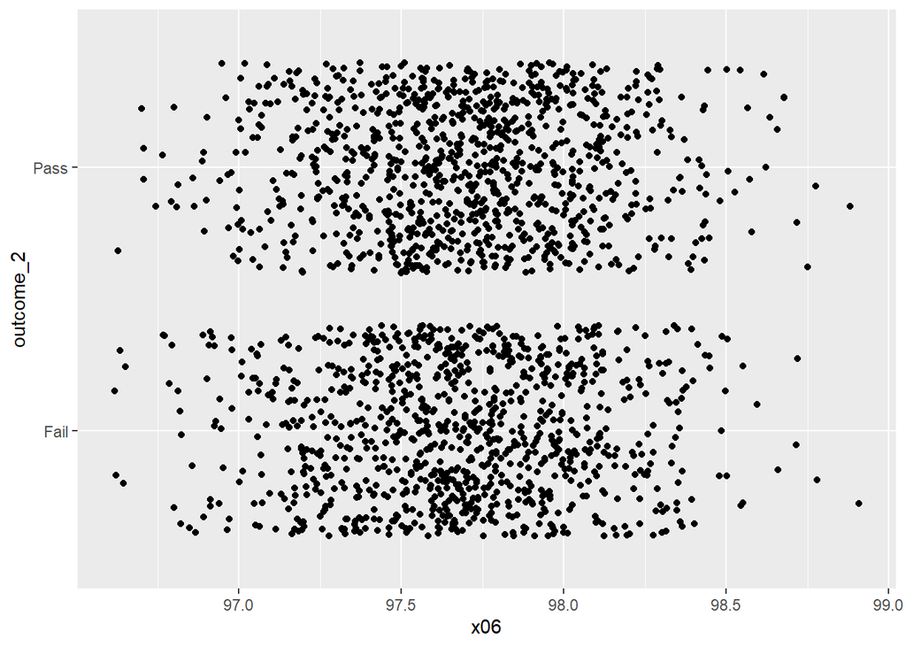

```r
df %>% ggplot(aes(x06,outcome_2)) + geom_jitter()
```

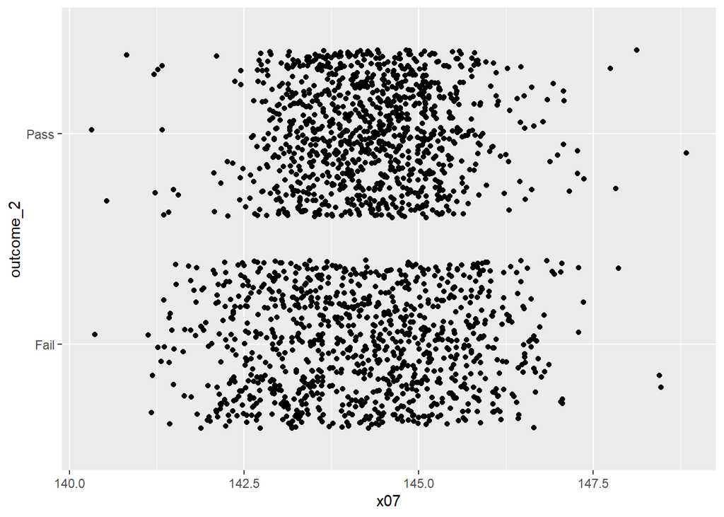

```r
df %>% ggplot(aes(x07,outcome_2)) + geom_jitter()
```

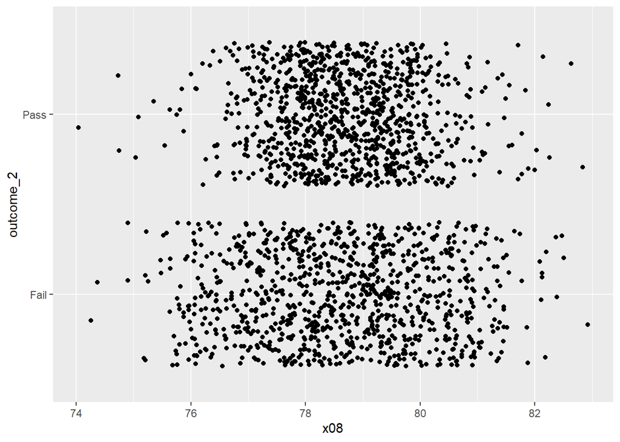

```r
df %>% ggplot(aes(x08,outcome_2)) + geom_jitter()
```

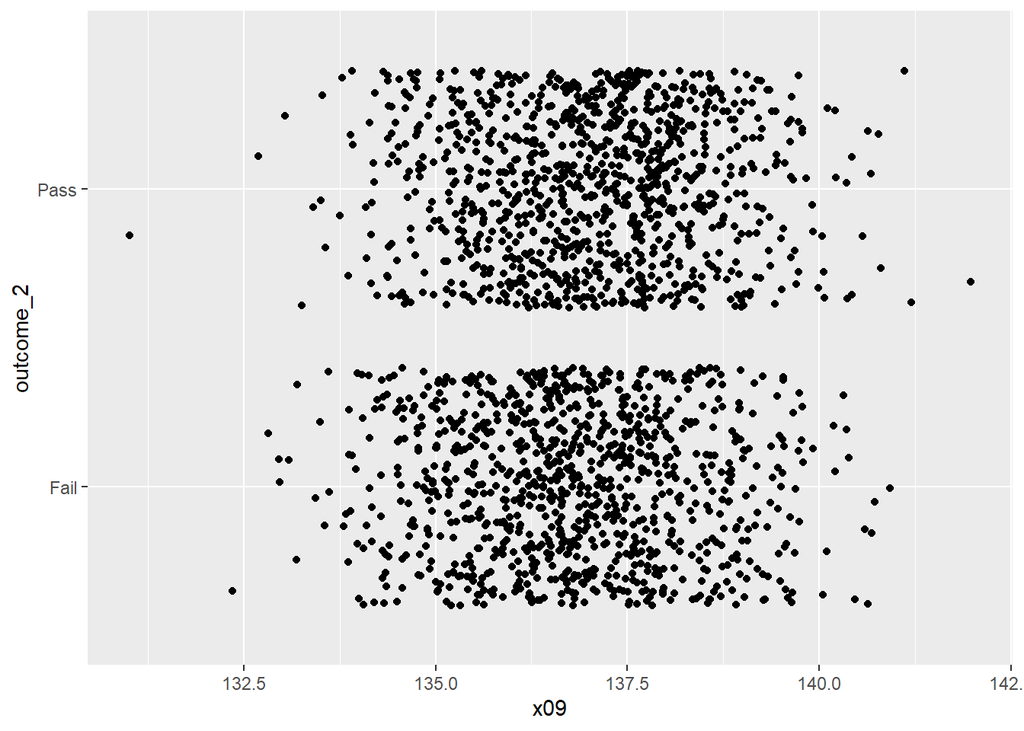

```r
df %>% ggplot(aes(x09,outcome_2)) + geom_jitter()
```

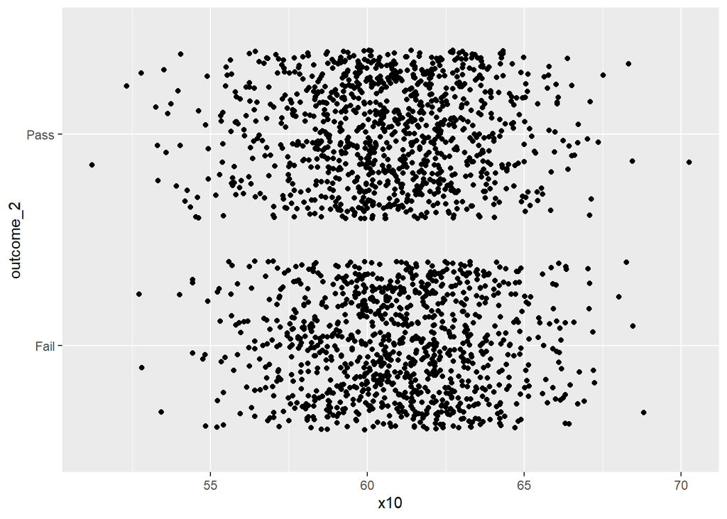

```r
df %>% ggplot(aes(x10,outcome_2)) + geom_jitter()
```

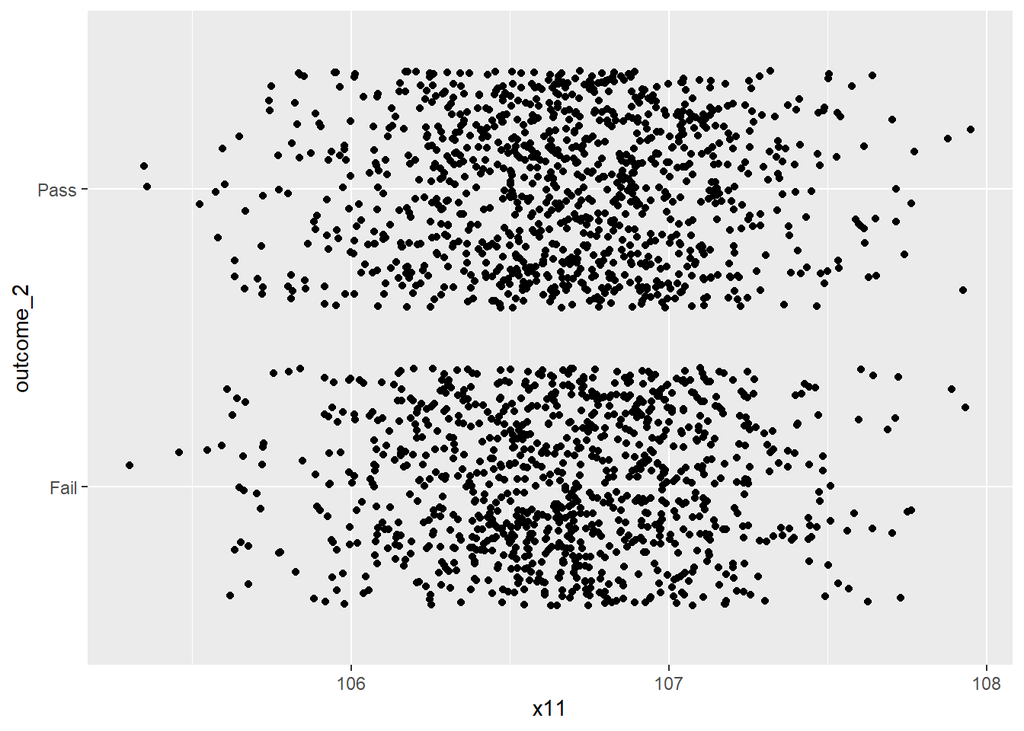

```r
df %>% ggplot(aes(x11,outcome_2)) + geom_jitter()
```

This visualization has demonstrated some things. The first is that some variables seem to be more strongly related with the outcome of response 1 than others. 1 and 2 in particular seem to have some sort of positive and negative relationship, respectively, whereas it is hard to see any trend among response_1 with variables 3 and 4. We also see that xA, which seemed above to have very little effect on the outcome, also seem to have little effect on response 1 (though A1 does seem more spread out, which may be important). xB on the other hand tells a different story. B2, which seemed to have the strongest performance above, seems to have results in which response1 is near zero, which makes sense given what we have seen from response1. Furthermore, B4, which had a very high failure rate, seems to have a wide spread of response1 results.

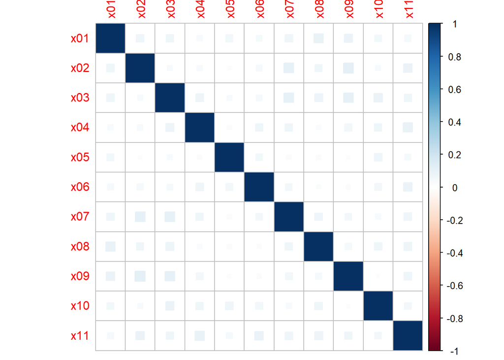

```r
df %>% select(x01,x02,x03,x04,x05,x06,x07,x08,x09,x10,x11) %>% cor() %>% corrplot::corrplot(method = "square")
```

The inputs themselves, on the whole, do not seem to be correlated at all! There is some relationship between x09 and other variables and the variables x01-x03, but on the whole, there does not seem to be much of a relationship. Something that is interesting, despite the fact that these relationships are not strong, is that almost none of the variables seems to be negatively correlated with each other, they all have very slight positive or neutral correlations.

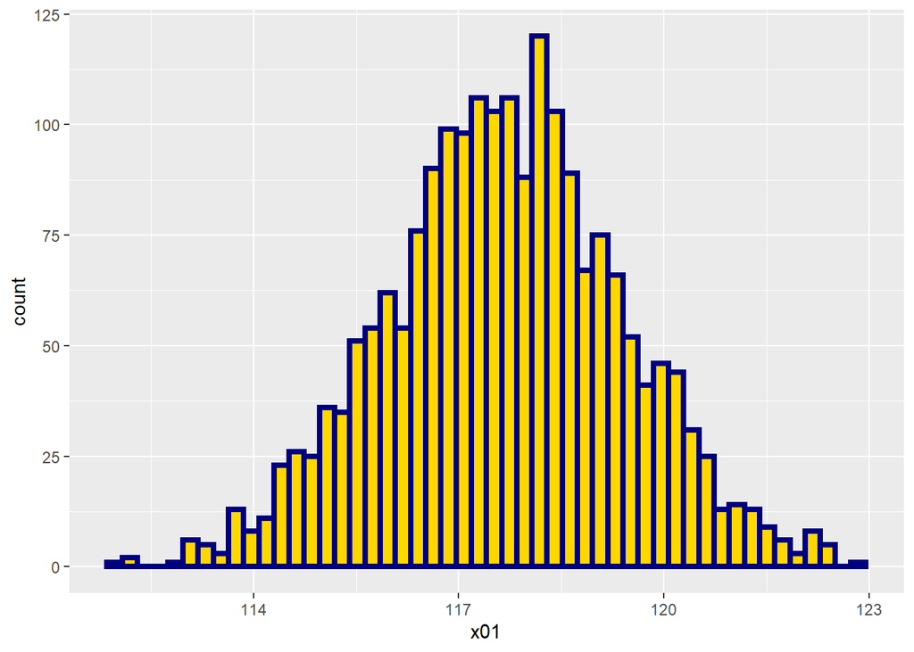

```r
df %>% ggplot(mapping = aes(x = x01)) + geom_histogram(bins = 50, color = "navyblue", fill = "gold", size = 1.55)
```

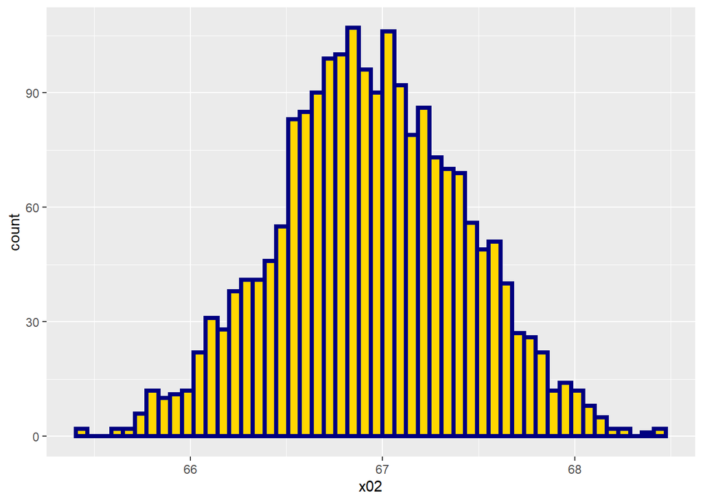

```r
df %>% ggplot(mapping = aes(x = x02)) + geom_histogram(bins = 50, color = "navyblue", fill = "gold", size = 1.55)
```

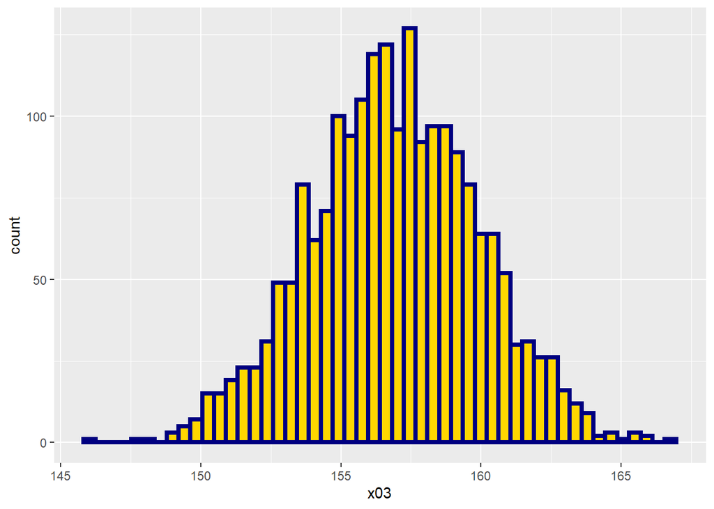

```r
df %>% ggplot(mapping = aes(x = x03)) + geom_histogram(bins = 50, color = "navyblue", fill = "gold", size = 1.55)
```

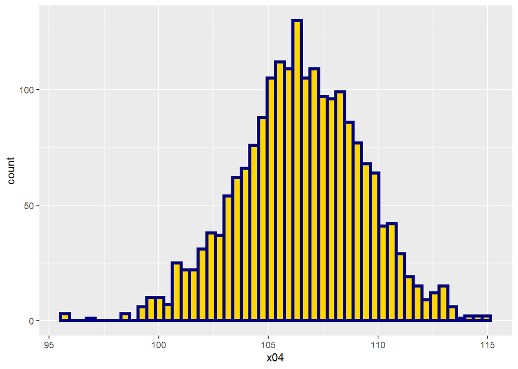

```r
df %>% ggplot(mapping = aes(x = x04)) + geom_histogram(bins = 50, color = "navyblue", fill = "gold", size = 1.55)
```

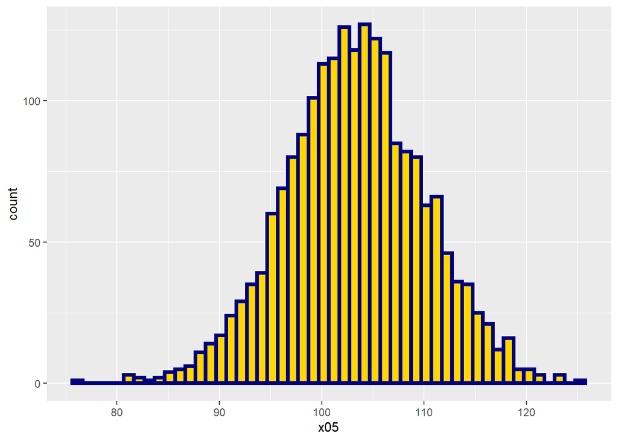

```r
df %>% ggplot(mapping = aes(x = x05)) + geom_histogram(bins = 50, color = "navyblue", fill = "gold", size = 1.55)
```

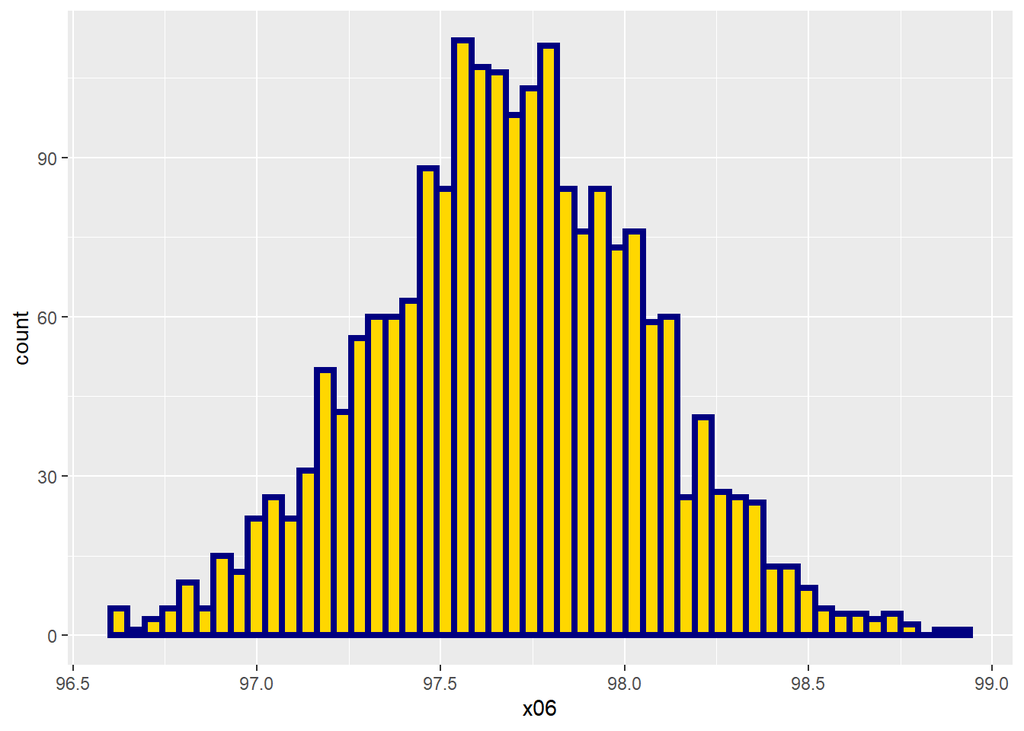

```r
df %>% ggplot(mapping = aes(x = x06)) + geom_histogram(bins = 50, color = "navyblue", fill = "gold", size = 1.55)
```

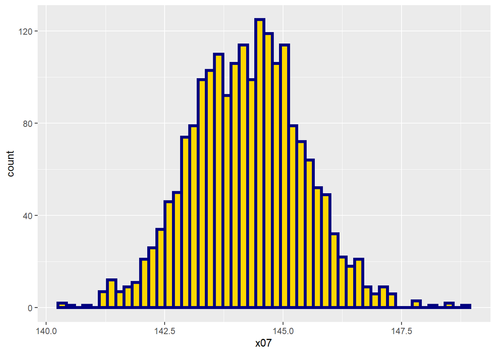

```r
df %>% ggplot(mapping = aes(x = x07)) + geom_histogram(bins = 50, color = "navyblue", fill = "gold", size = 1.55)
```

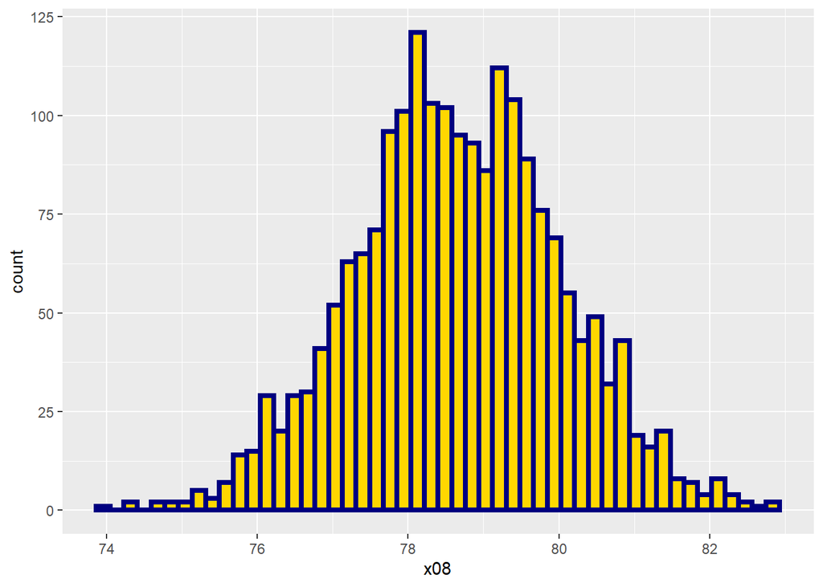

```r
df %>% ggplot(mapping = aes(x = x08)) + geom_histogram(bins = 50, color = "navyblue", fill = "gold", size = 1.55)
```

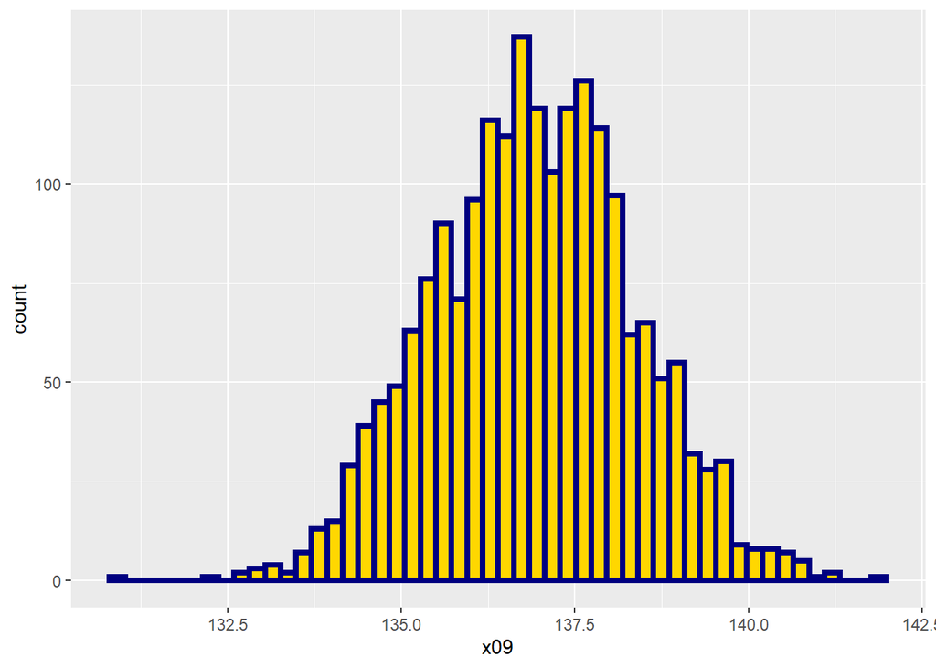

```r
df %>% ggplot(mapping = aes(x = x09)) + geom_histogram(bins = 50, color = "navyblue", fill = "gold", size = 1.55)
```

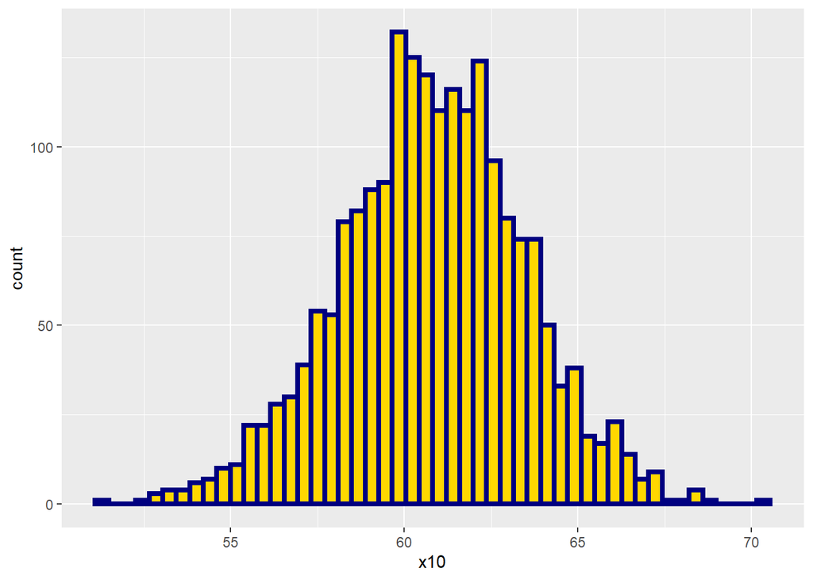

```r
df %>% ggplot(mapping = aes(x = x10)) + geom_histogram(bins = 50, color = "navyblue", fill = "gold", size = 1.55)
```

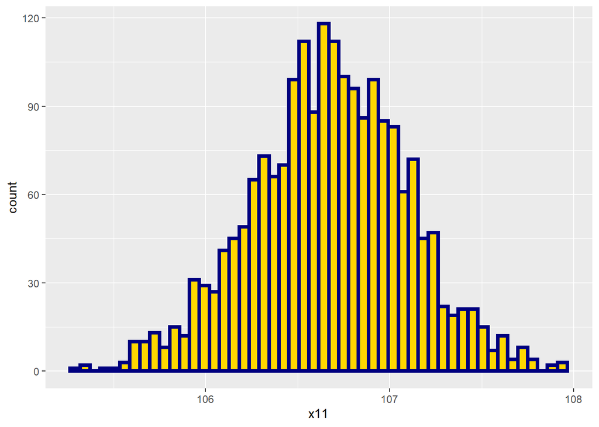

```r
df %>% ggplot(mapping = aes(x = x11)) + geom_histogram(bins = 50, color = "navyblue", fill = "gold", size = 1.55)
```

Every single continuous variables seems to be normally distributed! They may have a different center or a larger or smaller spread, but all of these seem like bell curves to me.

##Part 2A: Regression Models

Let’s fit some linear regression models! In order to choose the best model, we will compare the models based on their adjusted R-squared values:

This is a function that normalizes inputs, it is essetially just a pre-processing step. There is an implicit assumption here that the continuous variables are normal, this assumption is confirmed by our visualizations of the continuous variables above.

```r
normalizer <- function(vector){

      vector <- (vector - mean(vector))/sd(vector)
      return (vector)
}
normal1 <- normalizer(step_1_df$x01)
normal2 <- normalizer(step_1_df$x02)
normal3 <- normalizer(step_1_df$x03)
normal4 <- normalizer(step_1_df$x04)
normal5 <- normalizer(step_1_df$x05)
normal6 <- normalizer(step_1_df$x06)
normal_step_1_df <- data.frame(normal1,normal2,normal3,normal4,normal5,normal6,df$xA,df$xB, df$response_1)
```

We will use a linear model in terms of the discrete variables, a linear model in terms of the continous variables, a linear model that consists of both, and a basis function. The basis function will add a x01^3, x01^2, and x03^2 term to the model that uses both discrete and continuous values. This decision was made because, from the original data visualization, it seems not unlikely that x01 has a cubic relationship with response_1, and x03 has a quadratic relationship with response_1.

```r
mod_discrete_lm <- lm(df.response_1 ~ df.xA + df.xB, normal_step_1_df)
mod_continuous_lm <- lm(df.response_1 ~ normal1 + normal2 + normal3 + normal4 + normal5 + normal6, normal_step_1_df)
mod_step_1_lm <- lm(df.response_1 ~ normal1 + normal2 + normal3 + normal4 + normal5 + normal6 + df.xA + df.xB, normal_step_1_df)
mod_step_1_basis_lm <- lm(df.response_1 ~ normal1 + normal2 + normal3 + normal4 + normal5 + normal6 + df.xA + df.xB + I(normal1^2) + I(normal1^3) + I(normal3^2), normal_step_1_df)
summary(mod_discrete_lm)
```

```
##
## Call:
## lm(formula = df.response_1 ~ df.xA + df.xB, data = normal_step_1_df)
##
## Residuals:
##      Min       1Q   Median       3Q      Max
## -26.2049  -2.6076  -0.2137   2.7004  26.1931
##
## Coefficients:
##             Estimate Std. Error t value Pr(>|t|)
## (Intercept)   3.3763     0.2426  13.915  < 2e-16 ***
## df.xAA2       0.3426     0.2051   1.670    0.095 .
## df.xBB2      -2.4703     0.2826  -8.743  < 2e-16 ***
## df.xBB3      -7.7089     0.2881 -26.759  < 2e-16 ***
## df.xBB4      -1.4109     0.3046  -4.632 3.85e-06 ***
## ---
## Signif. codes:  0 '***' 0.001 '**' 0.01 '*' 0.05 '.' 0.1 ' ' 1
##
## Residual standard error: 4.543 on 2008 degrees of freedom
## Multiple R-squared:  0.2954, Adjusted R-squared:  0.294
## F-statistic: 210.5 on 4 and 2008 DF,  p-value: < 2.2e-16
```

```r
summary(mod_continuous_lm)
```

```
##
## Call:
## lm(formula = df.response_1 ~ normal1 + normal2 + normal3 + normal4 +
##     normal5 + normal6, data = normal_step_1_df)
##
## Residuals:
##      Min       1Q   Median       3Q      Max
## -25.9007  -2.1221   0.0251   2.2287  22.5315
##
## Coefficients:
##             Estimate Std. Error t value Pr(>|t|)
## (Intercept)   0.5003     0.1079   4.636 3.78e-06 ***
## normal1       1.7578     0.1087  16.174  < 2e-16 ***
## normal2      -1.6355     0.1084 -15.090  < 2e-16 ***
## normal3       0.4574     0.1086   4.212 2.64e-05 ***
## normal4       0.2178     0.1086   2.006   0.0450 *
## normal5       0.2701     0.1083   2.493   0.0127 *
## normal6       0.1206     0.1085   1.111   0.2669
## ---
## Signif. codes:  0 '***' 0.001 '**' 0.01 '*' 0.05 '.' 0.1 ' ' 1
##
## Residual standard error: 4.842 on 2006 degrees of freedom
## Multiple R-squared:  0.2003, Adjusted R-squared:  0.1979
## F-statistic: 83.75 on 6 and 2006 DF,  p-value: < 2.2e-16
```

```r
summary(mod_step_1_lm)
```

```
##
## Call:
## lm(formula = df.response_1 ~ normal1 + normal2 + normal3 + normal4 +
##     normal5 + normal6 + df.xA + df.xB, data = normal_step_1_df)
##
## Residuals:
##      Min       1Q   Median       3Q      Max
## -21.8852  -2.1475  -0.1666   2.0917  19.4622
##
## Coefficients:
##             Estimate Std. Error t value Pr(>|t|)
## (Intercept)  3.31935    0.20990  15.814  < 2e-16 ***
## normal1      1.48503    0.08790  16.895  < 2e-16 ***
## normal2     -2.01272    0.08823 -22.811  < 2e-16 ***
## normal3      0.19296    0.08808   2.191   0.0286 *
## normal4      0.10461    0.08758   1.194   0.2324
## normal5     -0.02135    0.08798  -0.243   0.8083
## normal6     -0.05803    0.08808  -0.659   0.5101
## df.xAA2      0.43235    0.17376   2.488   0.0129 *
## df.xBB2     -2.40800    0.25396  -9.482  < 2e-16 ***
## df.xBB3     -7.86836    0.24447 -32.186  < 2e-16 ***
## df.xBB4     -1.27307    0.27461  -4.636 3.78e-06 ***
## ---
## Signif. codes:  0 '***' 0.001 '**' 0.01 '*' 0.05 '.' 0.1 ' ' 1
##
## Residual standard error: 3.843 on 2002 degrees of freedom
## Multiple R-squared:  0.4973, Adjusted R-squared:  0.4948
## F-statistic:   198 on 10 and 2002 DF,  p-value: < 2.2e-16
```

```r
summary(mod_step_1_basis_lm)
```

```
##
## Call:
## lm(formula = df.response_1 ~ normal1 + normal2 + normal3 + normal4 +
##     normal5 + normal6 + df.xA + df.xB + I(normal1^2) + I(normal1^3) +
##     I(normal3^2), data = normal_step_1_df)
##
## Residuals:
##      Min       1Q   Median       3Q      Max
## -25.0089  -1.8930  -0.0261   1.9848  22.6555
##
## Coefficients:
##              Estimate Std. Error t value Pr(>|t|)
## (Intercept)   2.58776    0.21860  11.838  < 2e-16 ***
## normal1       0.52570    0.13949   3.769 0.000169 ***
## normal2      -2.01993    0.08516 -23.718  < 2e-16 ***
## normal3       0.19614    0.08499   2.308 0.021108 *
## normal4       0.08541    0.08454   1.010 0.312522
## normal5      -0.02467    0.08493  -0.290 0.771517
## normal6      -0.04297    0.08501  -0.505 0.613307
## df.xAA2       0.45142    0.16770   2.692 0.007166 **
## df.xBB2      -2.44472    0.24507  -9.976  < 2e-16 ***
## df.xBB3      -7.80800    0.23601 -33.083  < 2e-16 ***
## df.xBB4      -1.32828    0.26508  -5.011 5.89e-07 ***
## I(normal1^2)  0.44850    0.05926   7.569 5.70e-14 ***
## I(normal1^3)  0.33354    0.03778   8.829  < 2e-16 ***
## I(normal3^2)  0.28546    0.06016   4.745 2.23e-06 ***
## ---
## Signif. codes:  0 '***' 0.001 '**' 0.01 '*' 0.05 '.' 0.1 ' ' 1
##
## Residual standard error: 3.708 on 1999 degrees of freedom
## Multiple R-squared:  0.5327, Adjusted R-squared:  0.5297
## F-statistic: 175.3 on 13 and 1999 DF,  p-value: < 2.2e-16
```

There is lots to love about all of the results in these models. The median is close to zero, Q1 and Q3 are about equally apart from the median, and the min and max values are almost equally apart in all three models (it is nice to work with normal data)! There is also much to learn from these models. The first thing that stuck out to me was that the model that only uses discrete variables performs better in every relevant metric (Rsquared, adjusted Rsquared, Redidual standard error). The models that incorporate both perform better than these (which is not surprising, they are acting with more degrees of freedom on more information). However, the fact that the models that incorporate both the continuous variables the discrete variables so significantly outperforms the models with either one individually tells us that both the continuous and discrete variables play a large roll in determining response_1, at least in part.

The best model appears to be the model with the custom basis. This model has the highest R^2 (as it should, because it uses the most arguments), but also has the highest adjusted R-squared values which penalizes the use of irrelevant terms. Based on the adjusted R-squared value, I would say the custom basis is currently the best model we have, we should check a coefficient plot to see how the coefficients of our best model compare with other models:

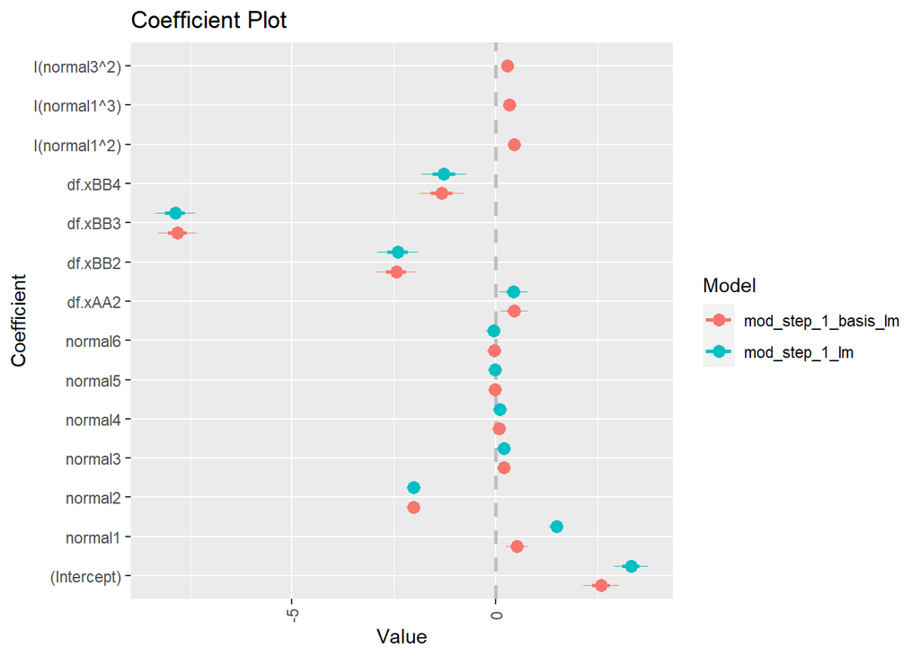

```r
coefplot::multiplot(mod_step_1_basis_lm, mod_step_1_lm)
```

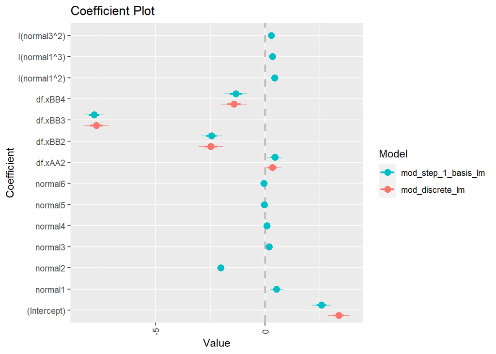

```r
coefplot::multiplot(mod_step_1_basis_lm, mod_discrete_lm)
```

```r
mod_step_1_lm_post <- stan_lm(df.response_1 ~ normal1 + normal2 + normal3 + normal4 + normal5 + normal6 + df.xA + df.xB, prior = R2(location = .5), data = normal_step_1_df, seed = 1245)
mod_step_1_basis_post <- stan_lm(df.response_1 ~ normal1 + normal2 + normal3 + normal4 + normal5 + normal6 + df.xA + df.xB + I(normal1^2) + I(normal1^3) + I(normal3^2), prior = R2(location = .5),  data = normal_step_1_df, seed = 1245)
summary(mod_step_1_lm_post)
```

```
##
## Model Info:
##  function:     stan_lm
##  family:       gaussian [identity]
##  formula:      df.response_1 ~ normal1 + normal2 + normal3 + normal4 + normal5 +
##     normal6 + df.xA + df.xB
##  algorithm:    sampling
##  sample:       4000 (posterior sample size)
##  priors:       see help('prior_summary')
##  observations: 2013
##  predictors:   11
##
## Estimates:
##                 mean   sd   10%   50%   90%
## (Intercept)    3.3    0.2  3.0   3.3   3.6
## normal1        1.5    0.1  1.4   1.5   1.6
## normal2       -2.0    0.1 -2.1  -2.0  -1.9
## normal3        0.2    0.1  0.1   0.2   0.3
## normal4        0.1    0.1  0.0   0.1   0.2
## normal5        0.0    0.1 -0.1   0.0   0.1
## normal6       -0.1    0.1 -0.2  -0.1   0.1
## df.xAA2        0.4    0.2  0.2   0.4   0.7
## df.xBB2       -2.4    0.2 -2.7  -2.4  -2.1
## df.xBB3       -7.8    0.2 -8.1  -7.8  -7.5
## df.xBB4       -1.3    0.3 -1.6  -1.3  -0.9
## sigma          3.8    0.1  3.8   3.8   3.9
## log-fit_ratio  0.0    0.0  0.0   0.0   0.0
## R2             0.5    0.0  0.5   0.5   0.5
##
## Fit Diagnostics:
##            mean   sd   10%   50%   90%
## mean_PPD 0.5    0.1  0.3   0.5   0.7
##
## The mean_ppd is the sample average posterior predictive distribution of the outcome variable (for details see help('summary.stanreg')).
##
## MCMC diagnostics
##               mcse Rhat n_eff
## (Intercept)   0.0  1.0  1992
## normal1       0.0  1.0  4156
## normal2       0.0  1.0  3524
## normal3       0.0  1.0  6285
## normal4       0.0  1.0  4574
## normal5       0.0  1.0  4754
## normal6       0.0  1.0  3591
## df.xAA2       0.0  1.0  3098
## df.xBB2       0.0  1.0  3452
## df.xBB3       0.0  1.0  2329
## df.xBB4       0.0  1.0  3461
## sigma         0.0  1.0  4531
## log-fit_ratio 0.0  1.0  2859
## R2            0.0  1.0  2812
## mean_PPD      0.0  1.0  4040
## log-posterior 0.1  1.0   765
##
## For each parameter, mcse is Monte Carlo standard error, n_eff is a crude measure of effective sample size, and Rhat is the potential scale reduction factor on split chains (at convergence Rhat=1).
```

```r
summary(mod_step_1_basis_post)
```

```
##
## Model Info:
##  function:     stan_lm
##  family:       gaussian [identity]
##  formula:      df.response_1 ~ normal1 + normal2 + normal3 + normal4 + normal5 +
##     normal6 + df.xA + df.xB + I(normal1^2) + I(normal1^3) + I(normal3^2)
##  algorithm:    sampling
##  sample:       4000 (posterior sample size)
##  priors:       see help('prior_summary')
##  observations: 2013
##  predictors:   14
##
## Estimates:
##                 mean   sd   10%   50%   90%
## (Intercept)    2.6    0.2  2.3   2.6   2.9
## normal1        0.5    0.1  0.3   0.5   0.7
## normal2       -2.0    0.1 -2.1  -2.0  -1.9
## normal3        0.2    0.1  0.1   0.2   0.3
## normal4        0.1    0.1  0.0   0.1   0.2
## normal5        0.0    0.1 -0.1   0.0   0.1
## normal6        0.0    0.1 -0.2   0.0   0.1
## df.xAA2        0.4    0.2  0.2   0.4   0.7
## df.xBB2       -2.4    0.2 -2.7  -2.4  -2.1
## df.xBB3       -7.8    0.2 -8.1  -7.8  -7.5
## df.xBB4       -1.3    0.3 -1.7  -1.3  -1.0
## I(normal1^2)   0.4    0.1  0.4   0.4   0.5
## I(normal1^3)   0.3    0.0  0.3   0.3   0.4
## I(normal3^2)   0.3    0.1  0.2   0.3   0.4
## sigma          3.7    0.1  3.6   3.7   3.8
## log-fit_ratio  0.0    0.0  0.0   0.0   0.0
## R2             0.5    0.0  0.5   0.5   0.5
##
## Fit Diagnostics:
##            mean   sd   10%   50%   90%
## mean_PPD 0.5    0.1  0.4   0.5   0.6
##
## The mean_ppd is the sample average posterior predictive distribution of the outcome variable (for details see help('summary.stanreg')).
##
## MCMC diagnostics
##               mcse Rhat n_eff
## (Intercept)   0.0  1.0  2536
## normal1       0.0  1.0  5171
## normal2       0.0  1.0  3742
## normal3       0.0  1.0  7213
## normal4       0.0  1.0  5219
## normal5       0.0  1.0  4033
## normal6       0.0  1.0  4021
## df.xAA2       0.0  1.0  4239
## df.xBB2       0.0  1.0  3696
## df.xBB3       0.0  1.0  2924
## df.xBB4       0.0  1.0  3877
## I(normal1^2)  0.0  1.0  5744
## I(normal1^3)  0.0  1.0  6423
## I(normal3^2)  0.0  1.0  5167
## sigma         0.0  1.0  5509
## log-fit_ratio 0.0  1.0  3693
## R2            0.0  1.0  3085
## mean_PPD      0.0  1.0  3902
## log-posterior 0.2  1.0   604
##
## For each parameter, mcse is Monte Carlo standard error, n_eff is a crude measure of effective sample size, and Rhat is the potential scale reduction factor on split chains (at convergence Rhat=1).
```

Using R^2 as our decisive parameter, the basis model is still best. Here is a visualization of the posterior coefficients where normal$n$ represents x0$n$.

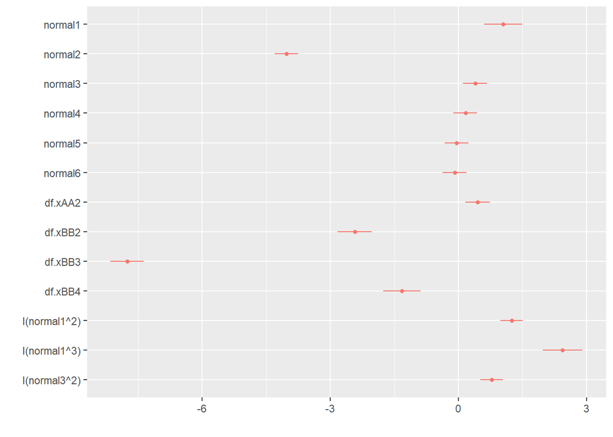

```r
dwplot(mod_step_1_basis_post)
```

The spread on the posterior of sigma seems to be small relative to the absolute size of the MLE of sigma.

##Part 2C: Regression Models

```r
my_ctrl <- trainControl(method = "repeatedcv", number = 5, repeats = 10)

my_ctrl_2 <- trainControl(method = "repeatedcv",
                             number = 5,
                             repeats = 10,
                             summaryFunction = twoClassSummary,
                             classProbs = TRUE,
                             savePredictions = TRUE)
```

Time to fit some regression models to predict response1! In addition to the required models, I will be training a lm function based on the basis function in the previous example:

```r
metric_1 = "RMSE"
lm_mod_step_1 <- train(response_1 ~ ., method = "lm", metric = metric_1, preProcess = c("center","scale"), trControl = my_ctrl, data = step_1_df)
lm_mod_step_1_basis <- train(response_1 ~ x01 + + I(x01^2) + I(x01^3) + x02 + I(x03) + I(x03^2) + x04 + x05 + x06 + xA + xB, method = "lm", preProcess = c("center","scale"), metric = metric_1, trControl = my_ctrl, data = step_1_df)
```

```r
summary(lm_mod_step_1)
```

```
##
## Call:
## lm(formula = .outcome ~ ., data = dat)
##
## Residuals:
##      Min       1Q   Median       3Q      Max
## -21.8852  -2.1475  -0.1666   2.0917  19.4622
##
## Coefficients:
##             Estimate Std. Error t value Pr(>|t|)
## (Intercept)  0.50031    0.08565   5.841 6.03e-09 ***
## xAA2         0.21350    0.08581   2.488   0.0129 *
## xBB2        -1.09361    0.11534  -9.482  < 2e-16 ***
## xBB3        -3.48080    0.10815 -32.186  < 2e-16 ***
## xBB4        -0.52102    0.11239  -4.636 3.78e-06 ***
## x01          1.48503    0.08790  16.895  < 2e-16 ***
## x02         -2.01272    0.08823 -22.811  < 2e-16 ***
## x03          0.19296    0.08808   2.191   0.0286 *
## x04          0.10461    0.08758   1.194   0.2324
## x05         -0.02135    0.08798  -0.243   0.8083
## x06         -0.05803    0.08808  -0.659   0.5101
## ---
## Signif. codes:  0 '***' 0.001 '**' 0.01 '*' 0.05 '.' 0.1 ' ' 1
##
## Residual standard error: 3.843 on 2002 degrees of freedom
## Multiple R-squared:  0.4973, Adjusted R-squared:  0.4948
## F-statistic:   198 on 10 and 2002 DF,  p-value: < 2.2e-16
```

```r
summary(lm_mod_step_1_basis)
```

```
##
## Call:
## lm(formula = .outcome ~ ., data = dat)
##
## Residuals:
##      Min       1Q   Median       3Q      Max
## -25.0089  -1.8930  -0.0261   1.9848  22.6555
##
## Coefficients:
##               Estimate Std. Error t value Pr(>|t|)
## (Intercept)  5.003e-01  8.264e-02   6.054 1.68e-09 ***
## x01          4.601e+03  5.275e+02   8.722  < 2e-16 ***
## `I(x01^2)`  -9.262e+03  1.056e+03  -8.774  < 2e-16 ***
## `I(x01^3)`   4.662e+03  5.281e+02   8.829  < 2e-16 ***
## x02         -2.020e+00  8.516e-02 -23.718  < 2e-16 ***
## `I(x03)`    -2.983e+01  6.329e+00  -4.714 2.60e-06 ***
## `I(x03^2)`   3.003e+01  6.329e+00   4.745 2.23e-06 ***
## x04          8.541e-02  8.454e-02   1.010  0.31252
## x05         -2.467e-02  8.493e-02  -0.290  0.77152
## x06         -4.297e-02  8.501e-02  -0.505  0.61331
## xAA2         2.229e-01  8.281e-02   2.692  0.00717 **
## xBB2        -1.110e+00  1.113e-01  -9.976  < 2e-16 ***
## xBB3        -3.454e+00  1.044e-01 -33.083  < 2e-16 ***
## xBB4        -5.436e-01  1.085e-01  -5.011 5.89e-07 ***
## ---
## Signif. codes:  0 '***' 0.001 '**' 0.01 '*' 0.05 '.' 0.1 ' ' 1
##
## Residual standard error: 3.708 on 1999 degrees of freedom
## Multiple R-squared:  0.5327, Adjusted R-squared:  0.5297
## F-statistic: 175.3 on 13 and 1999 DF,  p-value: < 2.2e-16
```

```r
glm_mod_step_1 <- train(response_1 ~ ., data = step_1_df,
                        method = "glm",
                        preProcess = c("center","scale"),
                        metric = metric_1,
                        trControl = my_ctrl)
glm_mod_step_1
```

```
## Generalized Linear Model
##
## 2013 samples
##    8 predictor
##
## Pre-processing: centered (10), scaled (10)
## Resampling: Cross-Validated (5 fold, repeated 10 times)
## Summary of sample sizes: 1611, 1611, 1610, 1609, 1611, 1610, ...
## Resampling results:
##
##   RMSE      Rsquared   MAE
##   3.857366  0.4919903  2.791398
```

```r
glmnet_mod_step_1 <- train(response_1 ~ . + .*. + .*.*., data = step_1_df,
                        method = "glmnet",
                        preProcess = c("center","scale"),
                        metric = metric_1,
                        trControl = my_ctrl)
glmnet_mod_step_1
```

```
## glmnet
##
## 2013 samples
##    8 predictor
##
## Pre-processing: centered (150), scaled (150)
## Resampling: Cross-Validated (5 fold, repeated 10 times)
## Summary of sample sizes: 1610, 1610, 1611, 1611, 1610, 1609, ...
## Resampling results across tuning parameters:
##
##   alpha  lambda       RMSE      Rsquared   MAE
##   0.10   0.005603354  3.799312  0.5069348  2.754021
##   0.10   0.056033543  3.855761  0.4923024  2.783661
##   0.10   0.560335429  3.867836  0.4902836  2.774795
##   0.55   0.005603354  3.824005  0.5005310  2.768271
##   0.55   0.056033543  3.854999  0.4925955  2.777092
##   0.55   0.560335429  3.952173  0.4785951  2.807499
##   1.00   0.005603354  3.836380  0.4973616  2.776122
##   1.00   0.056033543  3.857086  0.4922942  2.774060
##   1.00   0.560335429  4.064139  0.4650028  2.878757
##
## RMSE was used to select the optimal model using the smallest value.
## The final values used for the model were alpha = 0.1 and lambda = 0.005603354.
```

```r
nnet_mod_step_1 <- train(response_1 ~ x01 + x02 + x03 + x04 + x05 + x06 + xA + xB, #Rstudio didn't like the original data frame for some reason
                        data = df,
                        method = "nnet",
                        metric = metric_1,
                        hidden = 8,
                        linear.output = TRUE,
                        preProcess = c("center","scale"),
                        trControl = my_ctrl,
                        trace = FALSE)

nnet_mod_step_1
```

```
## Neural Network
##
## 2013 samples
##    8 predictor
##
## Pre-processing: centered (10), scaled (10)
## Resampling: Cross-Validated (5 fold, repeated 10 times)
## Summary of sample sizes: 1611, 1609, 1610, 1611, 1611, 1610, ...
## Resampling results across tuning parameters:
##
##   size  decay  RMSE      Rsquared   MAE
##   1     0e+00  5.196152  0.2046497  3.601002
##   1     1e-04  5.169121  0.2514595  3.567438
##   1     1e-01  5.140161  0.3157898  3.535300
##   3     0e+00  5.201644  0.1980999  3.604283
##   3     1e-04  5.163475  0.2602575  3.555975
##   3     1e-01  5.123907  0.3640799  3.507504
##   5     0e+00  5.202772  0.1988426  3.607341
##   5     1e-04  5.160801  0.2652818  3.552102
##   5     1e-01  5.117048  0.3894580  3.496647
##
## RMSE was used to select the optimal model using the smallest value.
## The final values used for the model were size = 5 and decay = 0.1.
```

```r
forest_mod_step_1 <- train(response_1 ~ x01 + x02 + x03 + x04 + x05 + x06 + xA + xB,
                        data = df,
                        method = "rf",
                        metric = metric_1,
                        linear.output = TRUE,
                        preProcess = c("center","scale"),
                        trControl = my_ctrl,
                        importance = TRUE)

forest_mod_step_1
```

```
## Random Forest
##
## 2013 samples
##    8 predictor
##
## Pre-processing: centered (10), scaled (10)
## Resampling: Cross-Validated (5 fold, repeated 10 times)
## Summary of sample sizes: 1611, 1610, 1610, 1610, 1611, 1610, ...
## Resampling results across tuning parameters:
##
##   mtry  RMSE      Rsquared   MAE
##    2    3.066435  0.7398299  2.131543
##    6    2.247899  0.8356852  1.646338
##   10    2.231499  0.8338533  1.654167
##
## RMSE was used to select the optimal model using the smallest value.
## The final value used for the model was mtry = 10.
```

```r
grad_tree_mod_step_1 <- train(response_1 ~ x01 + x02 + x03 + x04 + x05 + x06 + xA + xB,
                        data = df,
                        method = "xgbTree",
                        metric = metric_1,
                        linear.output = TRUE,
                        preProcess = c("center","scale"),
                        trControl = my_ctrl,
                        importance = TRUE)
```

```r
grad_tree_mod_step_1
```

```
## eXtreme Gradient Boosting
##
## 2013 samples
##    8 predictor
##
## Pre-processing: centered (10), scaled (10)
## Resampling: Cross-Validated (5 fold, repeated 10 times)
## Summary of sample sizes: 1610, 1610, 1610, 1612, 1610, 1611, ...
## Resampling results across tuning parameters:
##
##   eta  max_depth  colsample_bytree  subsample  nrounds  RMSE      Rsquared
##   0.3  1          0.6               0.50        50      3.969010  0.4636926
##   0.3  1          0.6               0.50       100      3.966271  0.4624740
##   0.3  1          0.6               0.50       150      3.998035  0.4554907
##   0.3  1          0.6               0.75        50      3.930026  0.4749863
##   0.3  1          0.6               0.75       100      3.943175  0.4689508
##   0.3  1          0.6               0.75       150      3.967118  0.4627676
##   0.3  1          0.6               1.00        50      3.905935  0.4825848
##   0.3  1          0.6               1.00       100      3.912556  0.4779261
##   0.3  1          0.6               1.00       150      3.933643  0.4719312
##   0.3  1          0.8               0.50        50      3.953908  0.4687590
##   0.3  1          0.8               0.50       100      3.965597  0.4627627
##   0.3  1          0.8               0.50       150      3.998520  0.4550087
##   0.3  1          0.8               0.75        50      3.927950  0.4757669
##   0.3  1          0.8               0.75       100      3.960055  0.4643193
##   0.3  1          0.8               0.75       150      3.973535  0.4610064
##   0.3  1          0.8               1.00        50      3.908723  0.4819125
##   0.3  1          0.8               1.00       100      3.913249  0.4776828
##   0.3  1          0.8               1.00       150      3.934576  0.4716473
##   0.3  2          0.6               0.50        50      3.202220  0.6532500
##   0.3  2          0.6               0.50       100      3.016834  0.6899857
##   0.3  2          0.6               0.50       150      2.894295  0.7143524
##   0.3  2          0.6               0.75        50      3.125358  0.6722456
##   0.3  2          0.6               0.75       100      2.960526  0.7036789
##   0.3  2          0.6               0.75       150      2.848246  0.7251664
##   0.3  2          0.6               1.00        50      3.081784  0.6835669
##   0.3  2          0.6               1.00       100      2.903745  0.7161277
##   0.3  2          0.6               1.00       150      2.787068  0.7375731
##   0.3  2          0.8               0.50        50      3.112727  0.6718289
##   0.3  2          0.8               0.50       100      2.910692  0.7112096
```

[output cut: 181 more lines]

```
##   1.893080
##   1.854034
##   1.781663
##   1.778934
##   1.807256
##   1.743354
##   1.736103
##
## Tuning parameter 'gamma' was held constant at a value of 0
## Tuning
##  parameter 'min_child_weight' was held constant at a value of 1
## RMSE was used to select the optimal model using the smallest value.
## The final values used for the model were nrounds = 150, max_depth = 3, eta
##  = 0.3, gamma = 0, colsample_bytree = 0.8, min_child_weight = 1 and subsample
##  = 1.
```

```r
knn_mod_step_1 <- train(response_1 ~ x01 + x02 + x03 + x04 + x05 + x06 + xA + xB,
                        data = df,
                        method = "knn",
                        metric = metric_1,
                        linear.output = TRUE,
                        preProcess = c("center","scale"),
                        trControl = my_ctrl)

knn_mod_step_1
```

```
## k-Nearest Neighbors
##
## 2013 samples
##    8 predictor
##
## Pre-processing: centered (10), scaled (10)
## Resampling: Cross-Validated (5 fold, repeated 10 times)
## Summary of sample sizes: 1612, 1610, 1610, 1610, 1610, 1611, ...
## Resampling results across tuning parameters:
##
##   k  RMSE      Rsquared   MAE
##   5  3.307413  0.6802610  2.277153
##   7  3.326316  0.7000236  2.274836
##   9  3.353628  0.7094342  2.292256
##
## RMSE was used to select the optimal model using the smallest value.
## The final value used for the model was k = 5.
```

```r
partial_least_squares <- train(response_1 ~ x01 + x02 + x03 + x04 + x05 + x06 + xA + xB,
                        data = df,
                        method = "pls",
                        metric = metric_1,
                        linear.output = TRUE,
                        preProcess = c("center","scale"),
                        trControl = my_ctrl)

partial_least_squares
```

```
## Partial Least Squares
##
## 2013 samples
##    8 predictor
##
## Pre-processing: centered (10), scaled (10)
## Resampling: Cross-Validated (5 fold, repeated 10 times)
## Summary of sample sizes: 1610, 1611, 1609, 1612, 1610, 1611, ...
## Resampling results across tuning parameters:
##
##   ncomp  RMSE      Rsquared   MAE
##   1      4.215763  0.3918826  3.082169
##   2      3.935029  0.4705429  2.803229
##   3      3.867595  0.4888220  2.805771
##
## RMSE was used to select the optimal model using the smallest value.
## The final value used for the model was ncomp = 3.
```

##Part 3: Binary Classification Option A

Time to fit some regression models to predict outcome2!

```r
metric_2 = "ROC"
```

```r
glm_mod_step_2 <- train(outcome_2 ~ .,
                        data = step_2_b_df,
                        method = "glm",
                        preProcess = c("center","scale"),
                        metric = metric_2,
                        trControl = my_ctrl_2)
glm_mod_step_2
```

```
## Generalized Linear Model
##
## 2013 samples
##    8 predictor
##    2 classes: 'Fail', 'Pass'
##
## Pre-processing: centered (10), scaled (10)
## Resampling: Cross-Validated (5 fold, repeated 10 times)
## Summary of sample sizes: 1611, 1610, 1610, 1611, 1610, 1610, ...
## Resampling results:
##
##   ROC        Sens       Spec
##   0.6228667  0.5431472  0.6474047
```

```r
glmnet_mod_step_2 <- train(outcome_2 ~ . + .*. + .*.*., data = step_2_b_df,
                        method = "glmnet",
                        preProcess = c("center","scale"),
                        metric = metric_2,
                        trControl = my_ctrl_2)
glmnet_mod_step_2
```

```
## glmnet
##
## 2013 samples
##    8 predictor
##    2 classes: 'Fail', 'Pass'
##
## Pre-processing: centered (150), scaled (150)
## Resampling: Cross-Validated (5 fold, repeated 10 times)
## Summary of sample sizes: 1611, 1610, 1610, 1610, 1611, 1610, ...
## Resampling results across tuning parameters:
##
##   alpha  lambda        ROC        Sens       Spec
##   0.10   0.0002019016  0.6923704  0.5669036  0.7093445
##   0.10   0.0020190161  0.6884236  0.5556345  0.7175179
##   0.10   0.0201901608  0.6867961  0.5477157  0.7150883
##   0.55   0.0002019016  0.6921397  0.5671066  0.7084708
##   0.55   0.0020190161  0.6858037  0.5517766  0.7151854
##   0.55   0.0201901608  0.6879507  0.5403046  0.7323992
##   1.00   0.0002019016  0.6920393  0.5684264  0.7074961
##   1.00   0.0020190161  0.6866409  0.5483249  0.7166450
##   1.00   0.0201901608  0.6880233  0.5203046  0.7574018
##
## ROC was used to select the optimal model using the largest value.
## The final values used for the model were alpha = 0.1 and lambda = 0.0002019016.
```

```r
nnet_mod_step_2 <- train(outcome_2 ~ .,
                        data = step_2_b_df,
                        method = "nnet",
                        metric = metric_2,
                        hidden = 8,
                        preProcess = c("center","scale"),
                        trControl = my_ctrl_2,
                        trace = FALSE)

nnet_mod_step_2
```

```
## Neural Network
##
## 2013 samples
##    8 predictor
##    2 classes: 'Fail', 'Pass'
##
## Pre-processing: centered (10), scaled (10)
## Resampling: Cross-Validated (5 fold, repeated 10 times)
## Summary of sample sizes: 1610, 1611, 1611, 1610, 1610, 1611, ...
## Resampling results across tuning parameters:
##
##   size  decay  ROC        Sens       Spec
##   1     0e+00  0.6119168  0.3629442  0.8531092
##   1     1e-04  0.6151531  0.3638579  0.8561269
##   1     1e-01  0.6145016  0.3895431  0.8386100
##   3     0e+00  0.7312856  0.6461929  0.7155330
##   3     1e-04  0.7331495  0.6535025  0.7120573
##   3     1e-01  0.7762943  0.7020305  0.7284869
##   5     0e+00  0.7475446  0.7047716  0.6795818
##   5     1e-04  0.7573839  0.6858883  0.7141804
##   5     1e-01  0.7968708  0.7216244  0.7454241
##
## ROC was used to select the optimal model using the largest value.
## The final values used for the model were size = 5 and decay = 0.1.
```

```r
forest_mod_step_2 <- train(outcome_2 ~ .,
                        data = step_2_b_df,
                        method = "rf",
                        metric = metric_2,
                        preProcess = c("center","scale"),
                        trControl = my_ctrl_2,
                        importance = TRUE)

forest_mod_step_2
```

```
## Random Forest
##
## 2013 samples
##    8 predictor
##    2 classes: 'Fail', 'Pass'
##
## Pre-processing: centered (10), scaled (10)
## Resampling: Cross-Validated (5 fold, repeated 10 times)
## Summary of sample sizes: 1610, 1611, 1611, 1610, 1610, 1611, ...
## Resampling results across tuning parameters:
##
##   mtry  ROC        Sens       Spec
##    2    0.7927065  0.7189848  0.7290717
##    6    0.7978347  0.7453807  0.7202306
##   10    0.7937388  0.7338071  0.7213943
##
## ROC was used to select the optimal model using the largest value.
## The final value used for the model was mtry = 6.
```

```r
grad_tree_mod_step_2 <- train(outcome_2 ~ .,
                        data = step_2_b_df,
                        method = "xgbTree",
                        metric = metric_2,
                        preProcess = c("center","scale"),
                        trControl = my_ctrl_2,
                        importance = TRUE)
```

```r
grad_tree_mod_step_2
```

```
## eXtreme Gradient Boosting
##
## 2013 samples
##    8 predictor
##    2 classes: 'Fail', 'Pass'
##
## Pre-processing: centered (10), scaled (10)
## Resampling: Cross-Validated (5 fold, repeated 10 times)
## Summary of sample sizes: 1610, 1611, 1610, 1611, 1610, 1610, ...
## Resampling results across tuning parameters:
##
##   eta  max_depth  colsample_bytree  subsample  nrounds  ROC        Sens
##   0.3  1          0.6               0.50        50      0.7782635  0.6519797
##   0.3  1          0.6               0.50       100      0.7791592  0.6665990
##   0.3  1          0.6               0.50       150      0.7767108  0.6665990
##   0.3  1          0.6               0.75        50      0.7810428  0.6522843
##   0.3  1          0.6               0.75       100      0.7826873  0.6610152
##   0.3  1          0.6               0.75       150      0.7798222  0.6617259
##   0.3  1          0.6               1.00        50      0.7807907  0.6366497
##   0.3  1          0.6               1.00       100      0.7835206  0.6522843
##   0.3  1          0.6               1.00       150      0.7825521  0.6556345
##   0.3  1          0.8               0.50        50      0.7805566  0.6637563
##   0.3  1          0.8               0.50       100      0.7788687  0.6654822
##   0.3  1          0.8               0.50       150      0.7756687  0.6673096
##   0.3  1          0.8               0.75        50      0.7809373  0.6492386
##   0.3  1          0.8               0.75       100      0.7817470  0.6653807
##   0.3  1          0.8               0.75       150      0.7791008  0.6635533
##   0.3  1          0.8               1.00        50      0.7807332  0.6370558
##   0.3  1          0.8               1.00       100      0.7832841  0.6535025
##   0.3  1          0.8               1.00       150      0.7824419  0.6582741
##   0.3  2          0.6               0.50        50      0.7879662  0.6865990
##   0.3  2          0.6               0.50       100      0.7803702  0.6860914
##   0.3  2          0.6               0.50       150      0.7790317  0.6909645
##   0.3  2          0.6               0.75        50      0.7920488  0.6856853
##   0.3  2          0.6               0.75       100      0.7880831  0.6831472
##   0.3  2          0.6               0.75       150      0.7847666  0.6842640
##   0.3  2          0.6               1.00        50      0.7961140  0.6845685
##   0.3  2          0.6               1.00       100      0.7918777  0.6890355
##   0.3  2          0.6               1.00       150      0.7890945  0.6873096
##   0.3  2          0.8               0.50        50      0.7908958  0.6918782
```

[output cut: 182 more lines]

```
##   0.7153663
##   0.7475662
##   0.7349339
##   0.7287014
##   0.7594213
##   0.7492105
##   0.7414355
##
## Tuning parameter 'gamma' was held constant at a value of 0
## Tuning
##  parameter 'min_child_weight' was held constant at a value of 1
## ROC was used to select the optimal model using the largest value.
## The final values used for the model were nrounds = 50, max_depth = 3, eta
##  = 0.3, gamma = 0, colsample_bytree = 0.8, min_child_weight = 1 and subsample
##  = 1.
```

```r
knn_mod_step_2 <- train(outcome_2 ~ .,
                        data = step_2_b_df,
                        method = "knn",
                        metric = metric_2,
                        preProcess = c("center","scale"),
                        trControl = my_ctrl_2)

knn_mod_step_2
```

```
## k-Nearest Neighbors
##
## 2013 samples
##    8 predictor
##    2 classes: 'Fail', 'Pass'
##
## Pre-processing: centered (10), scaled (10)
## Resampling: Cross-Validated (5 fold, repeated 10 times)
## Summary of sample sizes: 1611, 1611, 1610, 1610, 1610, 1610, ...
## Resampling results across tuning parameters:
##
##   k  ROC        Sens       Spec
##   5  0.6964235  0.5512690  0.7423244
##   7  0.7052368  0.5487310  0.7542941
##   9  0.7090810  0.5323858  0.7695496
##
## ROC was used to select the optimal model using the largest value.
## The final value used for the model was k = 9.
```

```r
partial_least_squares_2 <- train(outcome_2 ~ .,
                        data = step_2_b_df,
                        method = "pls",
                        metric = metric_2,
                        preProcess = c("center","scale"),
                        trControl = my_ctrl_2)

partial_least_squares_2
```

```
## Partial Least Squares
##
## 2013 samples
##    8 predictor
##    2 classes: 'Fail', 'Pass'
##
## Pre-processing: centered (10), scaled (10)
## Resampling: Cross-Validated (5 fold, repeated 10 times)
## Summary of sample sizes: 1610, 1611, 1610, 1611, 1610, 1610, ...
## Resampling results across tuning parameters:
##
##   ncomp  ROC        Sens       Spec
##   1      0.6157043  0.5099492  0.6744243
##   2      0.6225742  0.5496447  0.6332801
##   3      0.6223332  0.5482234  0.6407611
##
## ROC was used to select the optimal model using the largest value.
## The final value used for the model was ncomp = 2.
```

#Part 4: Binary Classification Option B

```r
glm_mod_step_3 <- train(outcome_2 ~ .,
                        data = step_2_a_df,
                        method = "glm",
                        preProcess = c("center","scale"),
                        metric = metric_2,
                        trControl = my_ctrl_2)
glm_mod_step_3
```

```
## Generalized Linear Model
##
## 2013 samples
##   13 predictor
##    2 classes: 'Fail', 'Pass'
##
## Pre-processing: centered (15), scaled (15)
## Resampling: Cross-Validated (5 fold, repeated 10 times)
## Summary of sample sizes: 1610, 1610, 1610, 1611, 1611, 1610, ...
## Resampling results:
##
##   ROC        Sens       Spec
##   0.6183268  0.5264975  0.6521416
```

```r
glmnet_mod_step_3 <- train(outcome_2 ~ . + .*. + .*.*., data = step_2_a_df,
                        method = "glmnet",
                        preProcess = c("center","scale"),
                        metric = metric_2,
                        trControl = my_ctrl_2)
glmnet_mod_step_3
```

```
## glmnet
##
## 2013 samples
##   13 predictor
##    2 classes: 'Fail', 'Pass'
##
## Pre-processing: centered (535), scaled (535)
## Resampling: Cross-Validated (5 fold, repeated 10 times)
## Summary of sample sizes: 1610, 1611, 1610, 1611, 1610, 1611, ...
## Resampling results across tuning parameters:
##
##   alpha  lambda        ROC        Sens       Spec
##   0.10   0.0001460282  0.6442058  0.5822335  0.6331793
##   0.10   0.0014602822  0.6257634  0.5394924  0.6451489
##   0.10   0.0146028219  0.6183113  0.5265990  0.6536093
##   0.55   0.0001460282  0.6418492  0.5803046  0.6324996
##   0.55   0.0014602822  0.6184058  0.5265990  0.6522463
##   0.55   0.0146028219  0.6192561  0.5220305  0.6591461
##   1.00   0.0001460282  0.6373029  0.5708629  0.6290950
##   1.00   0.0014602822  0.6183315  0.5267005  0.6524433
##   1.00   0.0146028219  0.6184788  0.5116751  0.6608960
##
## ROC was used to select the optimal model using the largest value.
## The final values used for the model were alpha = 0.1 and lambda = 0.0001460282.
```

```r
nnet_mod_step_3 <- train(outcome_2 ~ .,
                        data = step_2_a_df,
                        method = "nnet",
                        metric = metric_2,
                        hidden = 8,
                        preProcess = c("center","scale"),
                        trControl = my_ctrl_2,
                        trace = FALSE)

nnet_mod_step_3
```

```
## Neural Network
##
## 2013 samples
##   13 predictor
##    2 classes: 'Fail', 'Pass'
##
## Pre-processing: centered (15), scaled (15)
## Resampling: Cross-Validated (5 fold, repeated 10 times)
## Summary of sample sizes: 1610, 1611, 1611, 1610, 1610, 1610, ...
## Resampling results across tuning parameters:
##
##   size  decay  ROC        Sens       Spec
##   1     0e+00  0.6015088  0.4124873  0.7888752
##   1     1e-04  0.6099310  0.4067005  0.8010680
##   1     1e-01  0.5934565  0.4313706  0.7784106
##   3     0e+00  0.6633414  0.6323858  0.6349534
##   3     1e-04  0.6769758  0.6274112  0.6460583
##   3     1e-01  0.7282346  0.6600000  0.6938565
##   5     0e+00  0.6833931  0.6279188  0.6518210
##   5     1e-04  0.6821157  0.6196954  0.6444708
##   5     1e-01  0.7349649  0.6568528  0.6978593
##
## ROC was used to select the optimal model using the largest value.
## The final values used for the model were size = 5 and decay = 0.1.
```

```r
forest_mod_step_3 <- train(outcome_2 ~ .,
                        data = step_2_a_df,
                        method = "rf",
                        metric = metric_2,
                        preProcess = c("center","scale"),
                        trControl = my_ctrl_2,
                        importance = TRUE)

forest_mod_step_3
```

```
## Random Forest
##
## 2013 samples
##   13 predictor
##    2 classes: 'Fail', 'Pass'
##
## Pre-processing: centered (15), scaled (15)
## Resampling: Cross-Validated (5 fold, repeated 10 times)
## Summary of sample sizes: 1611, 1611, 1610, 1610, 1610, 1610, ...
## Resampling results across tuning parameters:
##
##   mtry  ROC        Sens       Spec
##    2    0.7875885  0.7127919  0.7222572
##    8    0.7960251  0.7615228  0.7046659
##   15    0.7897751  0.7463959  0.7073900
##
## ROC was used to select the optimal model using the largest value.
## The final value used for the model was mtry = 8.
```

```r
grad_tree_mod_step_3 <- train(outcome_2 ~ .,
                        data = step_2_a_df,
                        method = "xgbTree",
                        metric = metric_2,
                        preProcess = c("center","scale"),
                        trControl = my_ctrl_2,
                        importance = TRUE)
```

```r
grad_tree_mod_step_3
```

```
## eXtreme Gradient Boosting
##
## 2013 samples
##   13 predictor
##    2 classes: 'Fail', 'Pass'
##
## Pre-processing: centered (15), scaled (15)
## Resampling: Cross-Validated (5 fold, repeated 10 times)
## Summary of sample sizes: 1611, 1610, 1610, 1611, 1610, 1610, ...
## Resampling results across tuning parameters:
##
##   eta  max_depth  colsample_bytree  subsample  nrounds  ROC        Sens
##   0.3  1          0.6               0.50        50      0.7725095  0.6517766
##   0.3  1          0.6               0.50       100      0.7743701  0.6756345
##   0.3  1          0.6               0.50       150      0.7716934  0.6746193
##   0.3  1          0.6               0.75        50      0.7741608  0.6534010
##   0.3  1          0.6               0.75       100      0.7786435  0.6725888
##   0.3  1          0.6               0.75       150      0.7762442  0.6779695
##   0.3  1          0.6               1.00        50      0.7735134  0.6428426
##   0.3  1          0.6               1.00       100      0.7790490  0.6663959
##   0.3  1          0.6               1.00       150      0.7792266  0.6701523
##   0.3  1          0.8               0.50        50      0.7709776  0.6569543
##   0.3  1          0.8               0.50       100      0.7722528  0.6717766
##   0.3  1          0.8               0.50       150      0.7722768  0.6764467
##   0.3  1          0.8               0.75        50      0.7745724  0.6516751
##   0.3  1          0.8               0.75       100      0.7760679  0.6717766
##   0.3  1          0.8               0.75       150      0.7754144  0.6750254
##   0.3  1          0.8               1.00        50      0.7737714  0.6436548
##   0.3  1          0.8               1.00       100      0.7790905  0.6656853
##   0.3  1          0.8               1.00       150      0.7794304  0.6727919
##   0.3  2          0.6               0.50        50      0.7791397  0.6812183
##   0.3  2          0.6               0.50       100      0.7764626  0.6847716
##   0.3  2          0.6               0.50       150      0.7737331  0.6845685
##   0.3  2          0.6               0.75        50      0.7882589  0.6899492
##   0.3  2          0.6               0.75       100      0.7848931  0.6938071
##   0.3  2          0.6               0.75       150      0.7813046  0.6928934
##   0.3  2          0.6               1.00        50      0.7893020  0.6840609
##   0.3  2          0.6               1.00       100      0.7892899  0.6864975
##   0.3  2          0.6               1.00       150      0.7866311  0.6872081
##   0.3  2          0.8               0.50        50      0.7805924  0.6872081
```

[output cut: 182 more lines]

```
##   0.7092470
##   0.7335629
##   0.7287914
##   0.7216941
##   0.7515553
##   0.7428946
##   0.7358811
##
## Tuning parameter 'gamma' was held constant at a value of 0
## Tuning
##  parameter 'min_child_weight' was held constant at a value of 1
## ROC was used to select the optimal model using the largest value.
## The final values used for the model were nrounds = 50, max_depth = 3, eta
##  = 0.3, gamma = 0, colsample_bytree = 0.8, min_child_weight = 1 and subsample
##  = 1.
```

```r
knn_mod_step_3 <- train(outcome_2 ~ .,
                        data = step_2_a_df,
                        method = "knn",
                        metric = metric_2,
                        preProcess = c("center","scale"),
                        trControl = my_ctrl_2)

knn_mod_step_3
```

```
## k-Nearest Neighbors
##
## 2013 samples
##   13 predictor
##    2 classes: 'Fail', 'Pass'
##
## Pre-processing: centered (15), scaled (15)
## Resampling: Cross-Validated (5 fold, repeated 10 times)
## Summary of sample sizes: 1610, 1611, 1610, 1611, 1610, 1611, ...
## Resampling results across tuning parameters:
##
##   k  ROC        Sens       Spec
##   5  0.6617040  0.4647716  0.7555449
##   7  0.6727517  0.4613198  0.7761629
##   9  0.6800600  0.4459898  0.7937717
##
## ROC was used to select the optimal model using the largest value.
## The final value used for the model was k = 9.
```

```r
partial_least_squares_3 <- train(outcome_2 ~ .,
                        data = step_2_a_df,
                        method = "pls",
                        metric = metric_2,
                        preProcess = c("center","scale"),
                        trControl = my_ctrl_2)

partial_least_squares_3
```

```
## Partial Least Squares
##
## 2013 samples
##   13 predictor
##    2 classes: 'Fail', 'Pass'
##
## Pre-processing: centered (15), scaled (15)
## Resampling: Cross-Validated (5 fold, repeated 10 times)
## Summary of sample sizes: 1611, 1610, 1610, 1611, 1610, 1611, ...
## Resampling results across tuning parameters:
##
##   ncomp  ROC        Sens       Spec
##   1      0.6190988  0.5511675  0.6205371
##   2      0.6182020  0.5221320  0.6547715
##   3      0.6175767  0.5240609  0.6526332
##
## ROC was used to select the optimal model using the largest value.
## The final value used for the model was ncomp = 1.
```

The Random Forest model seems to be best for maximizing the ROC curve and maximizing Accuracy.

#Part 5: Analysis

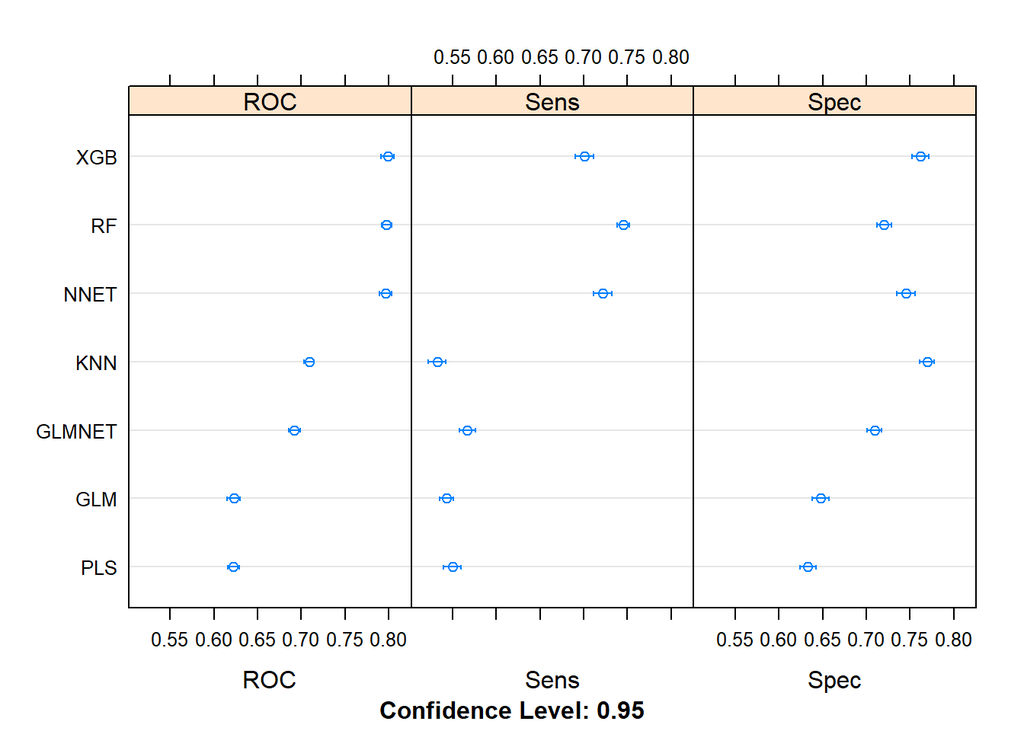

```r
models_roc_compare <- resamples(list(GLM = glm_mod_step_2,
                                    GLMNET = glmnet_mod_step_2,
                                    NNET = nnet_mod_step_2,
                                    RF = forest_mod_step_2,
                                    XGB = grad_tree_mod_step_2,
                                    KNN = knn_mod_step_2,
                                    PLS = partial_least_squares_2))

dotplot(models_roc_compare)
```

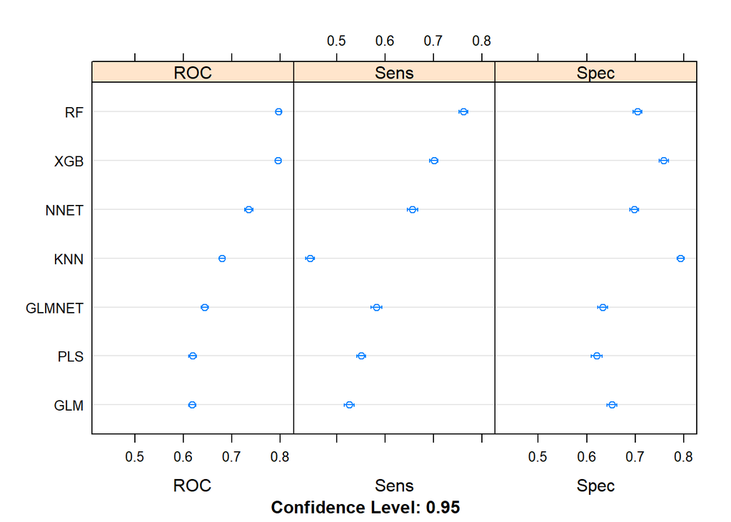

```r
models_roc_compare <- resamples(list(GLM = glm_mod_step_3,
                                    GLMNET = glmnet_mod_step_3,
                                    NNET = nnet_mod_step_3,
                                    RF = forest_mod_step_3,
                                    XGB = grad_tree_mod_step_3,
                                    KNN = knn_mod_step_3,
                                    PLS = partial_least_squares_3))

dotplot(models_roc_compare)
```

As displayed above, the random forest model is the model that tends to classify the most failures correctly. This seems to happen regardless of whether or not we make predictions with response_01 or with the 11 original inputs. In regards to whether or not it is better to predict using all of the inputs or predict using response_1, it does seem that predicting using response_1 does give us a significant boost in accuracy in the neural network case, which is relevant because the neural network appears to be the second best model. The second best model appears to be the neural network, as it has about the same ROC curve as XGB in the instance where we are predicting with response_1, and it has higher sensitivity in this case as well (which is important because we are in the business of predicting failures).

```r
model_pred_results <- forest_mod_step_2$pred %>% tibble::as_tibble() %>%
  filter(mtry == forest_mod_step_2$bestTune$mtry) %>%
  select(pred, obs, Pass, Fail, rowIndex, Resample) %>%
  mutate(model_name = "RF") %>%
  bind_rows(nnet_mod_step_2$pred %>% tibble::as_tibble() %>%
              filter(size == nnet_mod_step_2$bestTune$size,
                     decay == nnet_mod_step_2$bestTune$decay) %>%
              select(pred, obs, Pass, Fail, rowIndex, Resample) %>%
              mutate(model_name = "NNET"))
```

```r
model_pred_results_2 <- forest_mod_step_3$pred %>% tibble::as_tibble() %>%
  filter(mtry == forest_mod_step_3$bestTune$mtry) %>%
  select(pred, obs, Pass, Fail, rowIndex, Resample) %>%
  mutate(model_name = "RF") %>%
  bind_rows(nnet_mod_step_3$pred %>% tibble::as_tibble() %>%
              filter(size == nnet_mod_step_3$bestTune$size,
                     decay == nnet_mod_step_3$bestTune$decay) %>%
              select(pred, obs, Pass, Fail, rowIndex, Resample) %>%
              mutate(model_name = "NNET"))
```

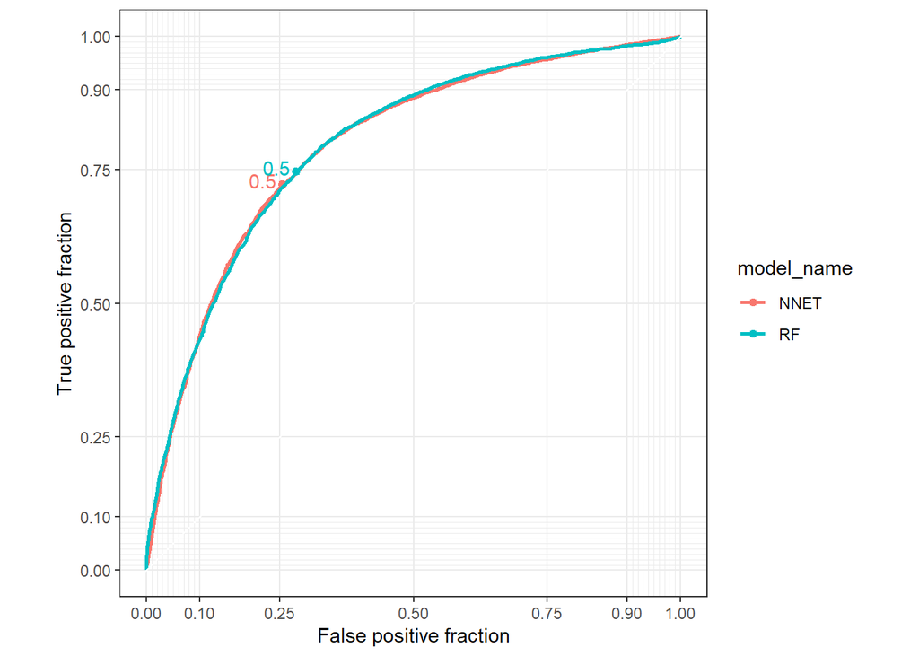

```r
model_pred_results %>%
  ggplot(aes(m = Fail,d = ifelse(obs=="Fail", 1, 0), color = model_name)) +
  geom_roc(cutoffs.at = 0.5) +
  coord_equal() +
  style_roc()
```

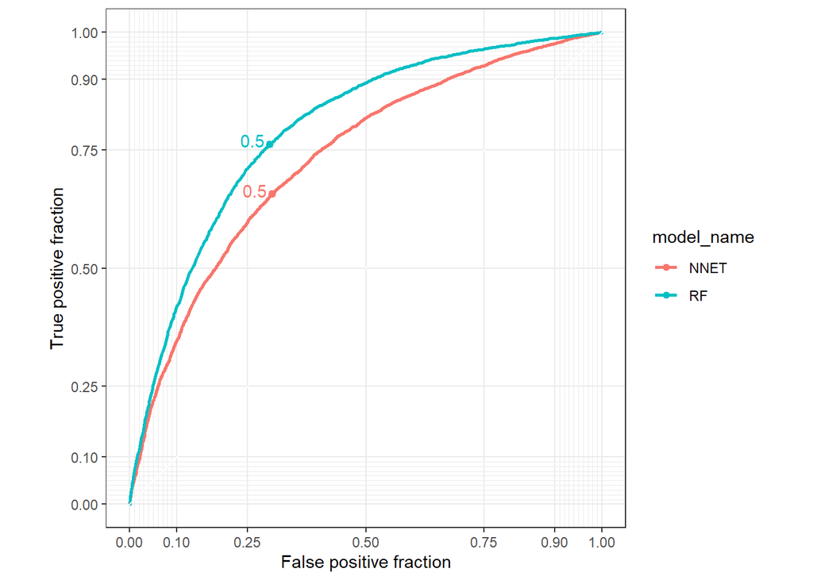

```r
model_pred_results_2 %>%
  ggplot(aes(m = Fail,d = ifelse(obs=="Fail", 1, 0), color = model_name)) +
  geom_roc(cutoffs.at = 0.5) +
  coord_equal() +
  style_roc()
```

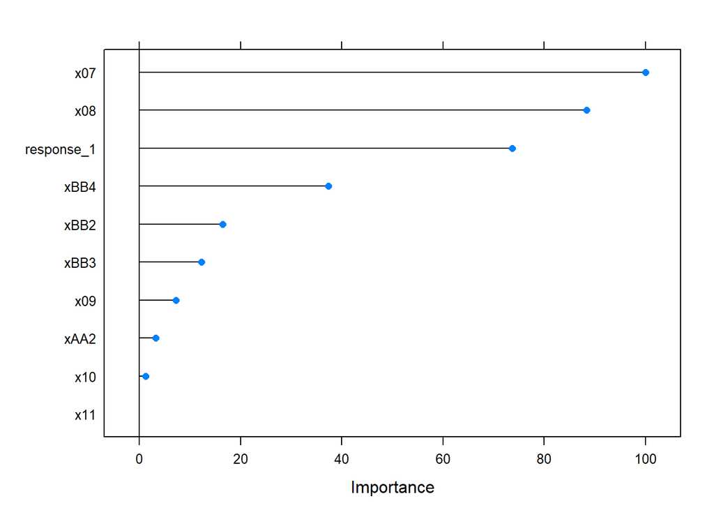

```r
plot(varImp(forest_mod_step_2))
```

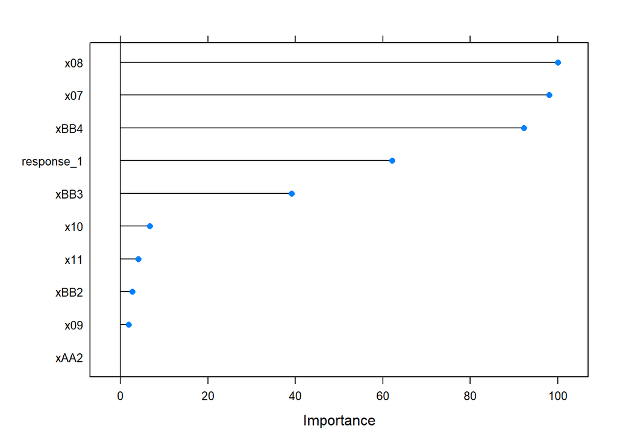

```r
plot(varImp(nnet_mod_step_2))
```

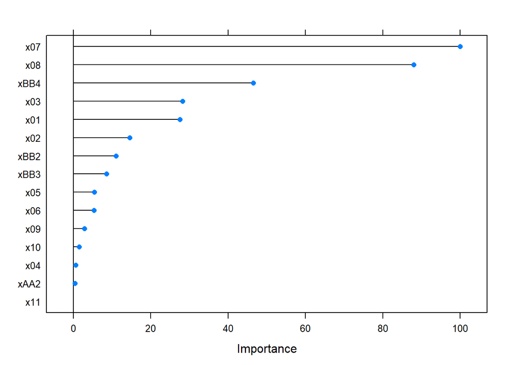

```r
plot(varImp(forest_mod_step_3))
```

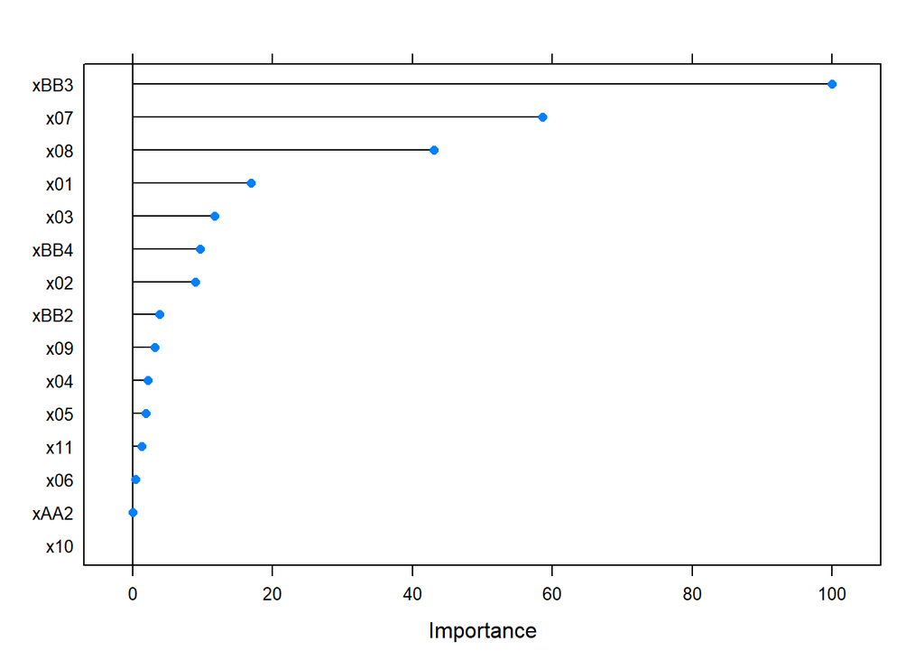

```r
plot(varImp(nnet_mod_step_3))
```

- Setting x07 somewhere between 143 and 145
- Setting x08 somewhere between 78 and 80
- Buying materials from B2 and avoiding B3 and B4 (unless B3 and B4 are cheaper options and the increased cost of failure is worth it)
- Setting x01 somewhere between 116 and 119
- Setting x03 somewhere between 155 and 160